# Notebook_Data_Analysis_CHN_Sample_Stage2_RR_V2

Lei Yue

2024-04-20

In “Notebook_Data_Analysis_CHN_Sample_Stage2_RR_V1.Rmd”， I preprocess the journal code data. In this Rmd(V2), we enter the informal process data.

**Special Note:** To enhance the readability and accessibility of this document, we have provided a concise explanation for the naming convention of data

Journal_: This prefix signifies data that has been coded and extracted from five mainstream Chinese journals.

BTS_: This indicates data sourced from large-scale international collaborations.

H1_: This indicates data use to test hypothesis 1.

H2_: This indicates data use to test hypothesis 2.

H3_: This indicates data use to test hypothesis 3.

Census_: This prefix represents Census data published by the National Bureau of Statistics of China.

CFPS2018_: This signifies data from the 2018 Chinese Family Panel Studies.

The majority of data adhere to these naming conventions, with the prefixes typically followed by descriptive and comprehensible demographic variable names or other relevant terms to clarify the data content.

Furthermore, if “Fig” appears in the data name, it signifies that the content represents a data visualization result. Similarly, the presence of “bayes” or “BF” indicates that the data or result pertains to the calculation of the Bayes factor.

Now, I start to analysis data. and the first thing is load packages.

# Install and Load packages

```r
rm(list = ls())

if (!require("pacman")) install.packages("pacman")

# use package "pacman" as loading R packages tools

pacman::p_load("tidyverse","here","rio","purrr")
pacman::p_load("geojsonsf","sf","RColorBrewer","ggspatial","patchwork","ggrepel","maps")
pacman::p_load("truncnorm","BayesFactor", "gtools", "bruceR")
```

And then, I loaded the data. The data primarily includes Census data, CFPS2018 data, Chinese journal coding data, and BTS data.

# Load data

## Load the data of stage 1, Chinese journals coding data, and BTS data

```r
load("df_Pre_Stage2_Journal_Code.Rdata")

load("df_chinese_subj_rr_stage1.Rdata")

load("BTS.Rdata")

BTS_coding <- readxl::read_xlsx("D://chin-subj//2_Data_Extraction//2_2_BTS//Chin_Subj_Proofreading_BTS_Target_Population.xlsx")
BTS_coding <- BTS_coding %>%
  dplyr::filter(Coder == "final")

## Here, I remove some data sets to reduce data set clutter.
rm(df_regionCode)
```

## combine raw data and coding data of BTS

```r
for (i in seq_along(BTS)) {

  current_df <- BTS[[i]]

  merged_df <- merge(current_df, BTS_coding, by = "Article_Id", all.x = TRUE)
  BTS[[i]] <- merged_df

}

## Process the target population of BTS_klein_et_al
# BTS_list_name <- names(BTS)

BTS[["BTS_Klein_et_al_2018_1"]]$Target_Population <- 2
BTS[["BTS_Klein_et_al_2018_2"]]$Target_Population <- 2
```

Here, I used self-defined function in Stage1 to calculate Bayesian multinomial test.

# Define a Func to calculate Bayesian multinomial test

## Algorithm in R

```
lbeta.xa <- sum(lgamma(alphas + counts)) - lgamma(sum(alphas + counts))
lbeta.a  <- sum(lgamma(alphas)) - lgamma(sum(alphas))

LogBF10 <- (lbeta.xa-lbeta.a) + (0 - sum(counts * log(thetas)))
```

Here, `alphas` defined the prior Dirichlet distribution, e.g., noninformative prior is a vector of $1$ s, `counts` are the observed frequencies.

To use the algorithm in R, we defined a function here:

```r
BayesMultiNomial <- function(dataset, factor, observed, expected, default_prior = TRUE, prior = NA){
  # datase - the input dataframe
  # factor - column name of the factor,
  # observed - column name of the column contains counts information for the observed,
  # expected - column name of the column contains counts information for the expected,
  # default_prior - whether use the default, defused prior
  # prior - priors defined by users

  fact_level <- dataset %>% dplyr::select(all_of(factor)) %>% dplyr::pull()
  observed_data <- dataset %>% dplyr::select(all_of(observed)) %>% dplyr::pull()
  names(observed_data) <- fact_level
  expected_data <- dataset %>% dplyr::select(all_of(expected)) %>% dplyr::pull()
  n_levels <- length(observed_data)


  if (default_prior & all(is.na(prior))) {
    prior <- rep(1, n_levels)
  } else{
    if (is.character(prior)){
      prior <- dataset %>% dplyr::select(all_of(prior)) %>% dplyr::pull()
    } else if (is.array(prior)){
      prior <-  prior
    } else if (is.numeric(prior)){
      prior <-  prior
    } else{
      print("prior much a column of the input data or a vector")
    }
  }

  alphas <- prior
  counts <- observed_data
  thetas <- expected_data

  if(sum(thetas) != 1) {
    thetas <- thetas/sum(thetas)
    }

  expected <- setNames(sum(counts)*thetas, names(counts))

  lbeta.xa <- sum(lgamma(alphas + counts)) - lgamma(sum(alphas + counts))
  lbeta.a  <- sum(lgamma(alphas)) - lgamma(sum(alphas))

  if (any(rowSums(cbind(thetas, counts)) == 0)) {
    LogBF10 <- (lbeta.xa-lbeta.a)
  } else {
     LogBF10 <- (lbeta.xa-lbeta.a) + (0 - sum(counts * log(thetas)))
  }

  BF <- data.frame(LogBF10 = LogBF10,
                   BF10    = exp(LogBF10),
                   BF01    = 1/exp(LogBF10))

  return(list(BF       = BF,
              expected = expected))

}
```

```r
Journal <- df_stage2_Journal_Code2 %>%
  dplyr::filter(is.na(Remark1) & !grepl("重复",Remark2)) %>%
  dplyr::filter(!grepl("2",Subjects_Recruitment_Area)) ## valid 1628 rows

## num of target population
Journal_targetpopulation <- Journal %>%
  dplyr::select(Article_IDs,Target_Population_N) %>%
  dplyr::distinct(Article_IDs,Target_Population_N)

table(Journal_targetpopulation$Target_Population_N)
```

```
##
##   1   2   3
## 622  24 354
```

```r
## num of articles/study
Journal_articles_num <- Journal %>%
  dplyr::distinct(Article_IDs) ## A total 1000 articles


Journal_study_num <- Journal %>%
  dplyr::distinct(Article_IDs,Study_Number) ## A total 1265 studies


## invalid papers
# Journal_invalid <- df_stage2_Journal_Code2 %>%
#   dplyr::filter(!is.na(Remark1)) %>%
#   dplyr::select(Article_IDs_N,Study_Number_N,Subjects_Group_N,
#                 Article_Title,Journal,Remark1,Remark2) %>%
#   dplyr::filter(grepl("2018",Article_IDs_N))
#
#
# writexl::write_xlsx(Journal_invalid,"Journal_invalid.xlsx")
# # Journal_articles_title <- Journal %>%
# #   dplyr::distinct(Article_Title)


# ## output `Journal` to help download bibliographic data from CNKI
# Journal_cnki <- Journal %>%
#   dplyr::select(Article_IDs_N,Article_Title,First_Author,Journal) %>%
#   dplyr::distinct(Article_IDs_N,.keep_all = TRUE)
#
# write.csv(Journal_cnki,"Journal_cnki.csv",row.names = FALSE)



# calculate exclude articles that only need code simple info
Journal_simple_info_articles <- df_stage2_Journal_Code2 %>%
  dplyr::filter(!is.na(Remark1)) %>%
  dplyr::distinct(Article_IDs,Remark1)

table(Journal_simple_info_articles$Remark1)
```

```
##
##       animal inapplicable       mining    non_human  qualitative    secondary
##            2            4            3            1            8           19
```

```r
## sample size sum
Journal_sample_size <- Journal %>%
  dplyr::select(Article_IDs,Study_Number,Subjects_Group,Sample_Size) %>%
  dplyr::mutate(Sample_Size = as.numeric(Sample_Size),
                Sample_Size = ifelse(Article_IDs == "20185082",33,Sample_Size))


sum(Journal_sample_size$Sample_Size,na.rm = TRUE)  ## 555,098
```

```
## [1] 555098
```

```r
## Here, I remove some data sets to reduce data set clutter.
# rm(Journal_articles_num,Journal_study_num,df_stage2_Journal_Code2)


## Save Journal to explore analysis
save(Journal, file ="Journal.Rdata")
```

Meanwhile, I process the special target population

```r
Journal_special_target_population <- Journal %>%
  dplyr::select(Article_IDs,Article_Title,Target_Population_N,Coding_Basis_N,Sample_Type_N) %>%
  dplyr::filter(Target_Population_N == 1) %>%
  dplyr::group_by(Article_IDs) %>%
  dplyr::slice(1)

# writexl::write_xlsx(Journal_special_target_population,"Journal_special_target_population.xlsx")

Journal_special_target_population2 <- readxl::read_xlsx("Journal_special_target_population.xlsx") %>%
  dplyr::select(Article_IDs,Article_Title,`Disscu.&.Conclu`, ,Target_Population_N,Coding_Basis_N,Recode_target_population)


## Save the special target population for exploration analyse

save(Journal_special_target_population2,file =  "Journal_special_target_population2.RData")
```

I try to classify special target population

```r
## college
Journal_college_TP <- Journal_special_target_population2 %>%
  dplyr::filter(grepl("大学生|研究生|大学新生",Recode_target_population)) %>%
  dplyr::filter(Recode_target_population == "大学生" | Recode_target_population == "研究生")
# %>%
#   dplyr::distinct(Article_IDs) ## 106

table(Journal_college_TP$Recode_target_population)
```

```
##
## 大学生 研究生
##    102      5
```

## The basic situation about BTS data

```r
BTS_Overview <- lapply(BTS,function(df){

  df <- df %>%
    dplyr::select(Article_Id,ISO3,ISO2)

  return(df)
})

BTS_Overview <- do.call(rbind,BTS_Overview)


BTS_Overview2 <- BTS_Overview %>%
  dplyr::filter(!is.na(ISO2)) %>%   ## ISO2 is used to subsequent visualize the spatial distribution in and filter out the data with countries as NA.
  dplyr::group_by(ISO2) %>%
  dplyr::summarise(n = n()) %>%
  dplyr::mutate(Proportion = n/sum(n)*100,
                Site = "BTS")


sum(BTS_Overview2$Proportion) ## 100
```

```
## [1] 100
```

```r
sum(BTS_Overview2$n) ## 1367084
```

```
## [1] 1367084
```

```r
29006/1367084
```

```
## [1] 0.02121742
```

```r
writexl::write_xlsx(BTS_Overview2,"D://chin-subj//2_Data_Extraction//2_2_BTS//BTS_participants.xlsx")

# ## n < 100 countries
# BTS_n100 <- BTS_Overview2 %>%
#   dplyr::filter(n < 100)
#
# ## n < 1000
# BTS_n1000 <- BTS_Overview2 %>%
#   dplyr::filter(n < 1000)
```

## The reported situation of Chinese Journals

```r
Journal_report <- Journal %>%
  dplyr::mutate(Subjects_Recruitment_Area = ifelse(Subjects_Recruitment_Area == 0, 0, 1),
                Sampling_Method = ifelse(Sampling_Method == 0, 0 ,1),
                SES_N = ifelse(SES_N == 0, 0, 1),
                Subjects_Recruitment_Method_N = ifelse(Subjects_Recruitment_Method_N == 0, 0, 1)) %>%
  dplyr::group_by(Article_IDs,Study_Number) %>%
  dplyr::summarise(Age = max(Age) > 0,
                   Sex = max(Gender) > 0,
                   Religion = max(Religious) > 0,
                   Ethnicity = max(Ethnicity) > 0,
                   Sampling_Method = max(Sampling_Method) > 0,
                   Recruitment_Area = max(Subjects_Recruitment_Area) > 0,
                   Recruitment_Method = max(Subjects_Recruitment_Method_N) > 0,
                   SES = max(SES_N) > 0,
                   .groups = "drop") %>%
  dplyr::select(3:last_col())


report_list <- list()

for (i in names(Journal_report)){


  report_table <- data.frame(table(Journal_report[[i]])) %>%
    dplyr::mutate(col_names = names(Journal_report[i]),
                  proportion = Freq / sum(Freq))

  report_list[[i]] <- report_table

}

Journal_report <- do.call(rbind, report_list) %>%
  dplyr::mutate(Var1 = ifelse(Var1 == "TRUE", "Reported","Unreported"))

### Calculate reported status of Educational_Attainment and Occupation
Journal_education_occupation_report <- Journal %>%
  dplyr::filter(Sample_Type_N %in% c(4,5)) %>%
  dplyr::group_by(Article_IDs,Study_Number) %>%
  dplyr::summarise(Educational_Attainment_N = max(Educational_Attainment_N) > 0,
                   Occupation_N = max(Occupation_N) > 0,.groups = "drop")   ### 306 studies

table(Journal_education_occupation_report$Educational_Attainment_N) ## FALSE 165 TRUE 141
```

```
##
## FALSE  TRUE
##   165   141
```

```r
table(Journal_education_occupation_report$Occupation_N)  ## FALSE 201 TRUE 105
```

```
##
## FALSE  TRUE
##   201   105
```

```r
Journal_education_occupation_table <- data.frame(Var1 = c("Unreported","Reported",
                                                            "Unreported","Reported"),
                                                   Freq = c(165,141,201,105),
                                                   col_names= c("Educational_Attainment",
                                                                "Educational_Attainment",
                                                                "Occupation","Occupation"),
                                                   proportion = c(165/(165+141),141/(165+141),201/(201+105),105/(201+105)))


Journal_report <- rbind(Journal_report,Journal_education_occupation_table) %>%
  dplyr::mutate(col_names = factor(col_names,
                                   labels = c("Sex","Age","Recruitment method",
                                              "Recruitment area","Educational attainment",
                                              "Occupation","Sampling method",
                                              "Socioeconomic status","Ethnicity","Religious belief"),
                                   levels = c("Sex","Age","Recruitment_Method",
                                              "Recruitment_Area","Educational_Attainment",
                                              "Occupation","Sampling_Method",
                                              "SES","Ethnicity","Religion")),
                proportion = proportion *100)



## calculate sum
Journal_report %>%
  dplyr::group_by(col_names) %>%
  dplyr::summarise(Prop = sum(proportion))
```

```
## # A tibble: 10 × 2
##    col_names               Prop
##    <fct>                  <dbl>
##  1 Sex                      100
##  2 Age                      100
##  3 Recruitment method       100
##  4 Recruitment area         100
##  5 Educational attainment   100
##  6 Occupation               100
##  7 Sampling method          100
##  8 Socioeconomic status     100
##  9 Ethnicity                100
## 10 Religious belief         100
```

### Visualize subjects information reported situations in Chinese journals

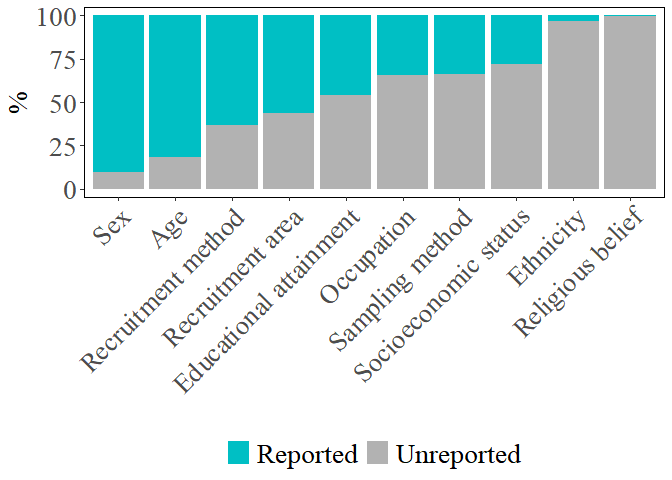

```r
Fig_Journal_report <- ggplot(Journal_report,aes(col_names,proportion,fill=Var1))+
  geom_col()+
  labs(x="",y="%")+
  theme_classic()+
  theme(panel.border =element_rect(fill=NA,color="black"),
        legend.position = "bottom",
        legend.box.spacing = unit(2,"pt"),
        legend.text = element_text(size = 20, family = "serif"),
        legend.title = element_blank(),
        axis.title = element_text(size = 20,family = "serif"),
        axis.text = element_text(size = 20,family = "serif"))+
  scale_x_discrete(guide = guide_axis(angle = 45))+
  scale_fill_manual(values = c("#00BFC4","#B2B2B2"))

Fig_Journal_report
```

```r
ggsave("Fig_Journal_report.pdf", Fig_Journal_report, device = "pdf", width=16, height = 9)

## Here, I remove some data sets to reduce data set clutter.
rm(report_list,report_table,i,Journal_education_occupation_report,Journal_education_occupation_table)
```

### Specific reports on some demographic categories

Age

```r
Journal_age_report_detail <- Journal %>%
  dplyr::select(Article_IDs,Study_Number,Subjects_Group,Age,M_age,SD_age,Other_age) %>%
  dplyr::filter(Age == 1)

### Age report studies num
Journal_age_report_detail_study_num <- Journal_age_report_detail %>%
    dplyr::distinct(Article_IDs,Study_Number) ## 1034 studies

### Age report papers num
Journal_age_report_detail_papers_num <- Journal_age_report_detail_study_num %>%
  dplyr::distinct(Article_IDs) ## 829 articles

### Age fuzzy report studies num
Journal_age_fuzzy_report <- Journal_age_report_detail %>%
  dplyr::filter(is.na(M_age))

## articles
Journal_age_fuzzy_report_article_num <- Journal_age_fuzzy_report %>%
  dplyr::distinct(Article_IDs) ## 121-6=115

## study
Journal_age_fuzzy_report_study_num <- Journal_age_fuzzy_report %>%
  dplyr::distinct(Article_IDs,Study_Number)  ## 142-6=136

## the above "-6" means aticles Mage coded in other_age, these articles are 20183340, 20183097, 20082227, 20214027, 20083017, 20181065


## Here, I remove some data sets to reduce data set clutter.
# rm(Journal_age_report_detail,Journal_age_report_detail_study_num,
#    Journal_age_fuzzy_report,Journal_age_fuzzy_report_study_num)


# writexl::write_xlsx(Journal, "Chin_Subj_articles_replaced.xlsx")
```

SES

```r
Journal_SES_report <- Journal %>%
  dplyr::select(Article_IDs,Study_Number,Subjects_Group,SES_N,SES_info_N) %>%
  dplyr::filter(SES_N != 0)


Journal_SES_report_studynum <- Journal_SES_report %>%
  dplyr::distinct(Article_IDs,Study_Number,SES_N) %>%
  dplyr::filter(Article_IDs != "20081025" & Article_IDs != "20183264") %>%  ## 2
  dplyr::mutate(ses_reported_ceta = ifelse(grepl(";",SES_N),1,0))  ## 339+2=341


## SES information is 5
Journal_SES_report_5 <- Journal_SES_report %>%
  dplyr::distinct(Article_IDs,Study_Number,SES_N) %>%
  dplyr::filter(Article_IDs != "20081025" & Article_IDs != "20183264") %>%
  dplyr::filter(SES_N == 5)  ## 10 studies

# table(Journal_SES_report_studynum$ses_reported_ceta)  ## 0(261)
```

## the reporting situation of BTS

```r
# BTS_colnames_list <- lapply(names(BTS), function(name) {
#   data.frame(
#     source_dataframe = name,
#     column_name = colnames(BTS[[name]])
#   )
# })
#
# # merge into one dataframe
# BTS_colnames <- do.call(rbind, BTS_colnames_list)
#
#
# ## exclude our add colnames
# BTS_colnames2 <- BTS_colnames %>%
#   dplyr::filter(!column_name %in% c("ISO2","ISO3","Target_Population","Coding_Basis",
#                                  "Countrycode","Countryfullname","Coder")) %>%
#   dplyr::count(column_name)
```

Process gender data from Chinese journals.

```r
## Filter for information-rich key variables
Journal_key_variable <- Journal %>%
  dplyr::select(Article_IDs,Study_Number,Subjects_Group_N,
                Sample_Size,Target_Population_N,Sample_Type_N,
                Gender,Male_Num,Female_Num,Age,M_age,SD_age,Other_age,
                Subjects_Recruitment_Area,Remark1,Remark2,Remark3)

# names(Journal_key_variable)

## Filter gender related variables
Journal_gender <- Journal_key_variable %>%
  dplyr::select(-c(10:17)) %>% ## not select age, remake and subjects recruitment area
  dplyr::filter(Gender == 1)

## Given that gender-related data includes both proportion-based records and headcount figures, these two types of data were processed separately.

Journal_gender_decimal <- Journal_gender %>%
  dplyr::filter(Male_Num < 1 & Female_Num < 1)

Journal_gender_integer <- Journal_gender %>%
  dplyr::filter(Male_Num > 1 | Female_Num > 1) %>%
  dplyr::mutate_at(vars(4:9),as.numeric)


## Multiple groups of data are removed during processing, so re-create the data.frame and then merge them.
Journal_gender_integer_add <- data.frame(Article_IDs = c("20185082","20213045","20213048","20213048"),
                                         Study_Number = c("1","1","1","2"),
                                         Subjects_Group_N = NA,
                                         Sample_Size = c(33,81,68,59),
                                         Target_Population_N = c(1,1,3,3),
                                         Sample_Type_N = c(3,5,5,5),
                                         Gender = 1,
                                         Male_Num = c(26,49,31,28),
                                         Female_Num = c(7,32,37,31))

Journal_gender_integer2 <- bind_rows(Journal_gender_integer,Journal_gender_integer_add)


## Process decimal
Journal_gender_decimal2 <- Journal_gender_decimal %>%
  dplyr::mutate_at(vars(4:9),as.numeric) %>%
  dplyr::mutate(Male_Num = floor(Sample_Size*Male_Num),
                Female_Num = Sample_Size - Male_Num)

## Combining journal gender data for both categories
Journal_gender2 <- bind_rows(Journal_gender_integer2,Journal_gender_decimal2)%>%
  dplyr::filter(!is.na(Male_Num))


## general
Journal_gender_general_papernum <- Journal_gender2 %>%
  dplyr::filter(Target_Population_N != 1) %>%
  dplyr::distinct(Article_IDs)

Journal_gender_general <- Journal_gender2 %>%
  dplyr::filter(Target_Population_N != 1) %>%
  dplyr::summarise(Male_Num = sum(Male_Num,na.rm = TRUE),
                   Female_Num = sum(Female_Num,na.rm = TRUE),
                   Male_Proportion = Male_Num/(Male_Num + Female_Num)*100,
                   Female_Proportion = Female_Num/(Male_Num + Female_Num)*100)

sum(Journal_gender_general$Male_Proportion)+sum(Journal_gender_general$Female_Proportion)
```

```
## [1] 100
```

```r
## special
Journal_gender_special <- Journal_gender2 %>%
  dplyr::filter(Target_Population_N == 1) %>%
  dplyr::summarise(Male_Num = sum(Male_Num,na.rm = TRUE),
                   Female_Num = sum(Female_Num,na.rm = TRUE),
                   Male_Proportion = Male_Num/(Male_Num + Female_Num)*100,
                   Female_Proportion = Female_Num/(Male_Num + Female_Num)*100)

sum(Journal_gender_special$Male_Proportion)+sum(Journal_gender_special$Female_Proportion)
```

```
## [1] 100
```

infants and toddlers & special target population

```r
## Filter studies targeting infants/toddlers from "Journal_special_target_population2"
Journal_gender_Infants_toddlers_TP <- Journal_special_target_population2 %>%
  dplyr::select(Article_IDs,Article_Title,Recode_target_population) %>%
  dplyr::filter(grepl("幼儿|岁儿童|学步儿|学前|学龄|低龄|婴儿", Recode_target_population)) %>%
  dplyr::filter(!grepl("幼儿父亲|幼儿教师|母亲|学前儿童父母|8|10|11|12",Recode_target_population))


## table paper num for targeted infants/todders
Journal_gender_Infants_toddlers_TP_tab <- Journal_gender_Infants_toddlers_TP %>%
  dplyr::distinct(Article_IDs)


## merge the above data.frame with "Journal" data.frame
Journal_gender_Infants_toddlers_TP_IDs <- Journal %>%
  dplyr::filter(Article_IDs_N %in% Journal_gender_Infants_toddlers_TP$Article_IDs) %>%
  dplyr::select(Article_IDs_N,Article_Title,Study_Number_N,Subjects_Group_N,
                M_age,SD_age,Other_age,Age,
                Gender,Male_Num,Female_Num,
                Sample_Type_N,Sample_Type_info_N) %>%
  dplyr::filter(Gender == 1) %>%
  dplyr::filter(!grepl("父亲|母亲|父母组",Subjects_Group_N)) %>%
  dplyr::left_join(Journal_gender_Infants_toddlers_TP,
                   by = c("Article_IDs_N" = "Article_IDs")) %>%
  dplyr::select(1:2,14:15,3:13)


## calculate gender num
## male num and female both are integer
Journal_gender_Infants_toddlers <- Journal_gender_Infants_toddlers_TP_IDs %>%
  dplyr::summarise(Male_Num = sum(as.numeric(Male_Num)),
                   Female_Num = sum(as.numeric(Female_Num)),
                   Male_Proportion = Male_Num/(Male_Num+Female_Num)*100,
                   Female_Proportion = Female_Num/(Male_Num+Female_Num)*100)

sum(Journal_gender_Infants_toddlers$Male_Proportion)+sum(Journal_gender_Infants_toddlers$Female_Proportion)
```

```
## [1] 100
```

Here, I remove some data sets to reduce data set clutter.

```r
rm(Journal_gender_decimal,Journal_gender_decimal2,
   Journal_gender_integer,Journal_gender_integer2,
   Journal_gender_integer_add,Journal_gender)
```

Process gender data from BTS.

```r
BTS_gender_list <- list()

for(i in seq_along(BTS)) {

  BTS_name <- names(BTS)[i]

 if ("Gender" %in% names(BTS[[i]])) {

  BTS_gender <- BTS[[i]] %>%
    dplyr::mutate(Gender = str_to_title(Gender)) %>%
    dplyr::filter(Gender == "Female" | Gender == "Male") %>%
    dplyr::mutate(Data_Source =  BTS_name)

  BTS_gender_list[[BTS_name]] <- BTS_gender

} else {

    cat(sprintf("Skipping '%s' because it does not contain a 'Gender' column.\n", BTS_name))
  }

}
```

Combine gender data from Chinese Journal and BTS.

```r
## Extracting Chinese data
BTS_gender_CHN <- lapply(BTS_gender_list, function(df){

  df %>%
    dplyr::filter(grepl("CHN", ISO3, ignore.case = TRUE)) %>%
    dplyr::filter(Data_Source != "BTS_Lucca_et_al_2024") %>%  ## no select special population
    dplyr::select(ISO3,Data_Source,Gender,Target_Population)

})

BTS_gender_CHN_general <- do.call(rbind,BTS_gender_CHN) %>%
  dplyr::group_by(Gender) %>%
  dplyr::summarise(n = n()) %>%
  dplyr::mutate(Proportion = n/sum(n)*100) %>%
  dplyr::ungroup() %>%
  dplyr::mutate(Data_Source = "BTS Chinese")

sum(BTS_gender_CHN_general$Proportion)
```

```
## [1] 100
```

```r
## Combine Chinese journal data and set factor
H1_gender_general <- BTS_gender_CHN_general %>%
  dplyr::add_row(Gender = c("Female","Male"), n = c(57570,48059),
                 Proportion = c(54.50208,45.49792),Data_Source = "Journal")   ## Here, enter data manually, data from data.frame "Journal_gender_general".


H1_gender_factor_general <- H1_gender_general %>%
  dplyr::filter(Gender == "Female") %>%
  dplyr::arrange(Proportion) %>%
  dplyr::pull(Data_Source)


H1_gender_general <- H1_gender_general %>%
  dplyr::mutate(Data_Source = factor(Data_Source,
                                     levels = H1_gender_factor_general))
```

Visualize gender data for Chinese journals and BTS.

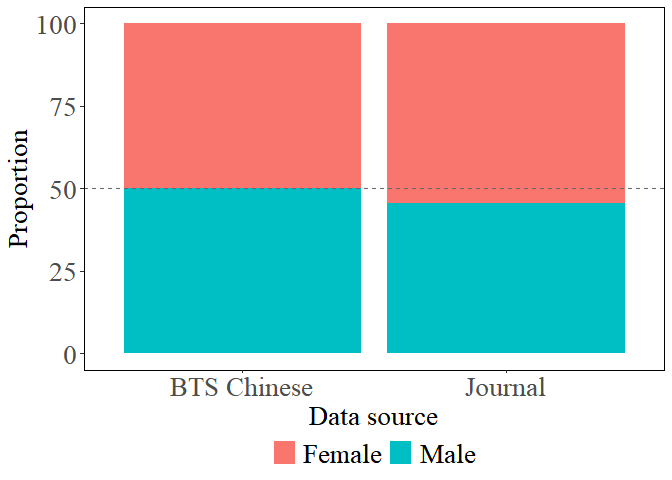

```r
H1_Fig_gender_general <- ggplot(data = H1_gender_general,aes(Data_Source,Proportion,fill = Gender))+
  geom_col()+
  geom_hline(yintercept = 50, linetype = "dashed", color = "#666666")+
  labs(y="Proportion")+
  theme_classic()+
  theme(panel.border =element_rect(fill=NA,color="black"),
        legend.position = "bottom",
        legend.box.spacing = unit(2,"pt"),
        legend.text = element_text(size = 20, family = "serif"),
        legend.title = element_blank(),
        axis.title = element_text(size = 20,family = "serif"),
        axis.text = element_text(size = 20,family = "serif"))+
  xlab("Data source")

H1_Fig_gender_general
```

Here I tested whether the gender proportion distribution from Chinese five journal data are similar to that of the BTS data. I used Bayesian multinomial test (Bayesian goodness-of-fit test) to examine whether the observed (BTS data) fit the expected (Chinese five journal data).

$H_0$: $\theta = c$, where $c$ is defined by Chinese five journal data; $H_1$: $\theta$ is free to vary.

I compared the general population between the two.

```r
H1_gender_bayes_general <- H1_gender_general %>%
  dplyr::select(1,3:4) %>%
  tidyr::pivot_wider(names_from = Data_Source, values_from = Proportion)

H1_BF_gender_general <- BayesMultiNomial(dataset = H1_gender_bayes_general,
                                             factor = "Gender",
                                             observed = "BTS Chinese",
                                             expected = "Journal")
```

However, within the general population, I found there is no difference between BTS Chinese data and Chinese five journal data, with $Log(BF_{10})$ = -1.6403875.

In this part, I will analysis gender based on the special target population. For the first research question, only Lucca et al.(2024)’ target population is special target population Specifically, it focuses on infants. Therefore, in specila target population, I will compare Lucca et al..(2024) with Chinese journal studies targeting infants/toddlers.

```r
Lucca_gender_special <- BTS[[19]] %>%
  dplyr::filter(ISO2 == "CN") %>%
  dplyr::group_by(Gender) %>%
  dplyr::summarise(n = n()) %>% ## Female 40, Male 53
  dplyr::ungroup() %>%
  dplyr::filter(!is.na(Gender)) %>%
  dplyr::mutate(Porportion = n/sum(n)*100,
                Data_Source = "Lucca")

sum(Lucca_gender_special$Porportion)
```

```
## [1] 100
```

```r
## create a data.frame that include two data.source
## Lucca'data from data.frame "Lucca_gender_special"
## Journal'data from data.frame "Journal_gender_Infants_toddlers"
H1_gender_bayes_special <- data.frame(Gender = c("Female","Male"),
                                      Lucca = c(43.01075,56.98925),
                                      Journal = c(48.4253,51.5747))

## calculate BF
H1_BF_gender_special <-  BayesMultiNomial(dataset = H1_gender_bayes_special,
                                          factor = "Gender",
                                          observed = "Lucca",
                                          expected = "Journal")
```

In the special population of infants and toddlers, I did not find difference between Lucca et al. (2024) and Chinese five journal data, with $Log(BF_{10})$ = -1.5046115.

At the end of gender data processing for hypothesis 1, I removed some data sets to reduce data set clutter.

```r
rm(H1_gender_factor_general,i,BTS_name)
```

### Age

Reprocess age data from Chinese journals.

```r
Journal_age <- Journal_key_variable %>%
  dplyr::select(-c(7:9,14:17)) %>%  ## not select gender, remake and subjects recruitment area
  dplyr::filter(Age == 1 & !is.na(Sample_Size)) %>%
  dplyr::filter(!is.na(M_age) & !is.na(SD_age))


## Filter M_age have multiple group data
Journal_strings_age <- Journal_age %>%
  dplyr::filter(grepl(";|:|：|,",M_age)) %>%
  dplyr::mutate(M_age = gsub("[;；]",";",M_age),
                SD_age = gsub("[;；]",";",SD_age)) %>%
  tidyr::separate_rows(c(M_age,SD_age),sep = ";") %>%
  dplyr::mutate(M_age = str_extract(M_age,"\\d+\\.\\d+|\\d+"),
                SD_age = str_extract(SD_age,"\\d+\\.\\d+|\\d+"))

## save `Journal_strings_age` and return to the original papers to re-enter and verify the data.
# writexl::write_xlsx(Journal_strings_age,"Journal_strings_age.xlsx")

Journal_strings_age_newdata <- readxl::read_xlsx("Journal_strings_age.xlsx") %>%
  dplyr::filter(!is.na(Sample_Size)) %>%
  dplyr::mutate_at(vars(4:9),as.numeric)


## Filter M_age only have single values data
Journal_single_age <- Journal_age %>%
  dplyr::filter(!grepl(";|:|：|,",M_age)) %>%
  dplyr::mutate_at(vars(4:9),as.numeric)


## Some articles contain the mean (M) and standard deviation (SD) of ages, but they was coded in "Other_Age". The V1 version of the document is stored separately.
Journal_otherage <- Journal_otherage %>%
  dplyr::mutate(Article_IDs = as.character(Article_IDs),
                Study_Number = as.character(Study_Number)) %>%
  dplyr::rename(M_age = 8,SD_age = 9,Other_age = 10) %>%
  dplyr::filter(!is.na(SD_age))

## Combining journal age data for three categories
Journal_age2 <- bind_rows(Journal_strings_age_newdata,Journal_single_age,Journal_otherage)


sum(Journal_age2$Sample_Size)  ## 370426
```

```
## [1] 370426
```

Since raw data is not available for papers in Chinese journals, I simulated the raw data using the method used in the Stges 1 of registration report. It is then combined with BTS and compared with census data.

First, I created a function that groups ages into five-year intervals for the purpose of creating a Population pyramid chart.

```r
Sim_Sens_mult_five <- function(Mean0, diff_age, SD0, sample_N=Sample_Size){


  ageData_five <-  c(pnorm(4, mean = Mean0, sd = SD0) * sample_N,
                 (pnorm(9, mean = Mean0, sd = SD0) - pnorm(4, mean = Mean0, sd = SD0)) *sample_N,
                 (pnorm(14, mean = Mean0, sd = SD0) - pnorm(9, mean = Mean0, sd = SD0)) *sample_N,
                 (pnorm(19, mean = Mean0, sd = SD0) - pnorm(14, mean = Mean0, sd = SD0)) *sample_N,
                 (pnorm(24, mean = Mean0, sd = SD0) - pnorm(19, mean = Mean0, sd = SD0)) *sample_N,
                 (pnorm(29, mean = Mean0, sd = SD0) - pnorm(24, mean = Mean0, sd = SD0)) *sample_N,
                 (pnorm(34, mean = Mean0, sd = SD0) - pnorm(29, mean = Mean0, sd = SD0)) *sample_N,
                 (pnorm(39, mean = Mean0, sd = SD0) - pnorm(34, mean = Mean0, sd = SD0)) *sample_N,
                 (pnorm(44, mean = Mean0, sd = SD0) - pnorm(39, mean = Mean0, sd = SD0)) *sample_N,
                 (pnorm(49, mean = Mean0, sd = SD0) - pnorm(44, mean = Mean0, sd = SD0)) *sample_N,
                 (pnorm(54, mean = Mean0, sd = SD0) - pnorm(49, mean = Mean0, sd = SD0)) *sample_N,
                 (pnorm(59, mean = Mean0, sd = SD0) - pnorm(54, mean = Mean0, sd = SD0)) *sample_N,
                 (pnorm(64, mean = Mean0, sd = SD0) - pnorm(59, mean = Mean0, sd = SD0)) *sample_N,
                 (pnorm(69, mean = Mean0, sd = SD0) - pnorm(64, mean = Mean0, sd = SD0)) *sample_N,
                 (pnorm(74, mean = Mean0, sd = SD0) - pnorm(69, mean = Mean0, sd = SD0)) *sample_N,
                 (pnorm(79, mean = Mean0, sd = SD0) - pnorm(74, mean = Mean0, sd = SD0)) *sample_N,
                 (pnorm(84, mean = Mean0, sd = SD0) - pnorm(79, mean = Mean0, sd = SD0)) *sample_N,
                 (pnorm(89, mean = Mean0, sd = SD0) - pnorm(84, mean = Mean0, sd = SD0)) *sample_N,
                 (pnorm(94, mean = Mean0, sd = SD0) - pnorm(89, mean = Mean0, sd = SD0)) *sample_N,
                 (1 - pnorm(94, mean = Mean0, sd = SD0)) * sample_N)


    # create a dataframe with ageData_five
  Sim_agefive_df <- setNames(data.frame(matrix(ncol = 2, nrow = 20)), c("ageBins", "sim1"))
  Sim_agefive_df$ageBins <- c("0~4","5~9","10~14","15~19","20~24",
                              "25~29","30~34","35~39","40~44","45~49",
                              "50~54","55~59","60~64","65~69","70~74",
                              "75~79","80~84","85~89", "90~94",">=95")
  Sim_agefive_df$sim1[1:20] <- ageData_five


  return(Sim_agefive_df)
}
```

I then continued to use the same steps to divide age into psychological developmental stages.

```r
Sim_Sens_mult_PsyStages <- function(Mean1, diff_age, SD1, sample_N=Sample_Size){


  ageData_PsyStages <-  c(pnorm(17, mean = Mean1, sd = SD1) * sample_N,
                          (pnorm(25, mean = Mean1, sd = SD1) - pnorm(17, mean = Mean1, sd = SD1)) *sample_N,
                          (pnorm(40, mean = Mean1, sd = SD1) - pnorm(25, mean = Mean1, sd = SD1)) *sample_N,
                          (pnorm(60, mean = Mean1, sd = SD1) - pnorm(40, mean = Mean1, sd = SD1)) *sample_N,
                          (1 - pnorm(60, mean = Mean1, sd = SD1)) * sample_N)


  # create a dataframe with ageData_PsyStages
  Sim_agePsyStages_df <- setNames(data.frame(matrix(ncol = 2, nrow = 5)), c("ageBins", "sim1"))
  Sim_agePsyStages_df$ageBins <- c("<=17", "18~25", "26~40", "41~60", ">=61")
  Sim_agePsyStages_df$sim1[1:5] <- ageData_PsyStages


  return(Sim_agePsyStages_df)
}
```

Meanwhile, I created func to process age data simulation in 10-year-old segment.

```r
Sim_Sens_mult_interval10 <- function(Mean2, diff_age2, SD2, sample_N2=Sample_Size){


  # 0~10, 11~20, 21~30, 31~40, 41~50, 51~60, 61~
  ageData_interval10 <-  c(pnorm(10, mean = Mean2, sd = SD2) * sample_N2,
                           (pnorm(20, mean = Mean2, sd = SD2) - pnorm(10, mean = Mean2, sd = SD2)) *sample_N2,
                           (pnorm(30, mean = Mean2, sd = SD2) - pnorm(20, mean = Mean2, sd = SD2)) *sample_N2,
                           (pnorm(40, mean = Mean2, sd = SD2) - pnorm(30, mean = Mean2, sd = SD2)) *sample_N2,
                           (pnorm(50, mean = Mean2, sd = SD2) - pnorm(40, mean = Mean2, sd = SD2)) *sample_N2,
                           (pnorm(60, mean = Mean2, sd = SD2) - pnorm(50, mean = Mean2, sd = SD2)) *sample_N2,
                           (1 - pnorm(60, mean = Mean2, sd = SD2)) * sample_N2
)


    # create a dataframe with ageData1 and ageData2:
  Sim_ageinterval10_df <- setNames(data.frame(matrix(ncol = 2, nrow = 7)), c("ageBins", "sim1"))
  Sim_ageinterval10_df$ageBins <- c("<=10", "11~20", "21~30", "31~40", "41~50", "51~60", ">=61")
  Sim_ageinterval10_df$sim1[1:7] <- ageData_interval10


  return(Sim_ageinterval10_df)
}
```

In the following part, I will calculate other age data based on different target population.The first is general population.

5-years-old

```r
Journal_age_general <-  Journal_age2 %>%
  dplyr::filter(Target_Population_N != 1)

Journal_age_general_papernum <- Journal_age2 %>%
  dplyr::filter(Target_Population_N != 1) %>%
  dplyr::distinct(Article_IDs)
## simulate different categories age data
### five-year-old
Sim_Journal_age_five1_general <- lapply(1:nrow(Journal_age_general),function(i){

  Sim_Sens_mult_five(Mean0 = Journal_age_general$M_age[i],
                diff_age = 0,
                SD0 = Journal_age_general$SD_age[i],
                sample_N = Journal_age_general$Sample_Size[i])

  })


Sim_Journal_age_five2_general <- do.call(rbind,Sim_Journal_age_five1_general)


Sim_Journal_age_five3_general <- Sim_Journal_age_five2_general %>%
  dplyr::group_by(ageBins) %>%
  dplyr::summarise(sim1 = round(sum(sim1,na.rm = TRUE))) %>%
  dplyr::ungroup() %>%
  dplyr::mutate(ageBins =factor(ageBins,
                                levels = c("0~4","5~9","10~14","15~19","20~24",
                                           "25~29","30~34","35~39","40~44","45~49",
                                           "50~54","55~59","60~64","65~69","70~74",
                                           "75~79","80~84","85~89", "90~94",">=95")))


## Calculate the sample difference between the coded data and the simulated data
sum(Journal_age_general$Sample_Size)-sum(Sim_Journal_age_five3_general$sim1)
```

```
## [1] -1
```

PsyStages

```r
Sim_Journal_age_PsyStages1_general <- lapply(1:nrow(Journal_age_general),function(i){

  Sim_Sens_mult_PsyStages(Mean1 = Journal_age_general$M_age[i],
                diff_age = 0,
                SD1 = Journal_age_general$SD_age[i],
                sample_N = Journal_age_general$Sample_Size[i])

  })


Sim_Journal_age_PsyStages2_general <- do.call(rbind,Sim_Journal_age_PsyStages1_general)


Sim_Journal_age_PsyStages3_general <- Sim_Journal_age_PsyStages2_general %>%
  dplyr::group_by(ageBins) %>%
  dplyr::summarise(sim1 = round(sum(sim1,na.rm = TRUE))) %>%
  dplyr::ungroup() %>%
  dplyr::mutate(ageBins =factor(ageBins,
                                levels = c("<=17","18~25","26~40","41~60", ">=61")))

## Calculate the sample difference between the coded data and the simulated data
sum(Journal_age_general$Sample_Size)-sum(Sim_Journal_age_PsyStages3_general$sim1,na.rm = TRUE)
```

```
## [1] -1
```

interval10

```r
Sim_Journal_age_interval101_general <- lapply(1:nrow(Journal_age_general),function(i){

  Sim_Sens_mult_interval10(Mean2 = Journal_age_general$M_age[i],
                diff_age2 = 0,
                SD2 = Journal_age_general$SD_age[i],
                sample_N2 = Journal_age_general$Sample_Size[i])

  })


Sim_Journal_age_interval102_general <- do.call(rbind,Sim_Journal_age_interval101_general)


## Use simulation function to process data.
Sim_Journal_age_interval103_general <- Sim_Journal_age_interval102_general %>%
  dplyr::group_by(ageBins) %>%
  dplyr::summarise(sim1 = round(sum(sim1,na.rm = TRUE))) %>%
  dplyr::ungroup() %>%
  dplyr::mutate(ageBins =factor(ageBins,
                                levels = c("<=10", "11~20", "21~30",
                                           "31~40", "41~50", "51~60", ">=61")))



## Calculate the sample difference between the coded data and the simulated data
sum(Journal_age_general$Sample_Size)-sum(Sim_Journal_age_interval103_general$sim1,na.rm = TRUE)
```

```
## [1] -1
```

As mentioned above, the special target population of BTS is only Lucca et al.(2024), its target population is babies, and there is no need to compare ages between BTS and Journals in age.

Process age data from BTS.

```r
BTS_age_list <- list()

for(i in seq_along(BTS)){

  BTS_name <- names(BTS)[i]

  if("Age" %in% names(BTS[[i]])){

    BTS_age <- BTS[[i]] %>%
      dplyr::filter(!is.na(Age) & !is.na(ISO3)) %>%
      dplyr::select(Article_Id,Age,Target_Population,ISO3) %>%
      dplyr::mutate(Age = as.numeric(Age)) %>%
      dplyr::mutate(ageBins = cut(Age,
                                breaks = c(-Inf,4.5,9.5,14.5,19.5,24.5,
                                           29.5,34.5,39.5,44.5,49.5,
                                           54.5,59.5,64.5,69.5,74.5,
                                           79.5,84.5,89.5,94.5,Inf),
                                labels = c("0~4","5~9","10~14","15~19","20~24",
                                 "25~29","30~34","35~39","40~44","45~49",
                                 "50~54","55~59","60~64","65~69","70~74",
                                 "75~79","80~84","85~89", "90~94",">=95" ),
                                levels = c("0~4","5~9","10~14","15~19","20~24",
                                 "25~29","30~34","35~39","40~44","45~49",
                                 "50~54","55~59","60~64","65~69","70~74",
                                 "75~79","80~84","85~89", "90~94",">=95" )))

BTS_age_list[[BTS_name]] <- BTS_age

} else {

    cat(sprintf("Skipping '%s' because it does not contain a 'Age' column.\n", BTS_name))
  }
}
```

```
## Skipping 'BTS_Atari_et_al_2020' because it does not contain a 'Age' column.
```

```r
## merge data.frame in list
BTS_age <-  bind_rows(BTS_age_list)
```

I filter Chinese age data from BTS, and combine BTS CHN data with Journals data. Considering the different target population, I process all data firstly.

```r
BTS_age_general_CHN <- BTS_age %>%
  dplyr::filter(ISO3 == "CHN" & (Target_Population == 2 | Target_Population == 3)) %>%
  dplyr::count(ageBins) %>%
  dplyr::mutate(Proportion = n/sum(n)*100,
                Data_Source = "BTS Chinese")


sum(BTS_age_general_CHN$Proportion)
```

```
## [1] 100
```

```r
## combine 2 dataframe
H1_age_general <- Sim_Journal_age_five3_general %>%
  dplyr::rename(n = 2) %>%
  dplyr::mutate(Proportion = n/sum(n)*100,
                Data_Source = "Journal") %>%
  dplyr::bind_rows(BTS_age_general_CHN) %>%
  dplyr::add_row(ageBins = ">=95",n = 0,
                 Proportion =0 ,Data_Source = "BTS Chinese")


H1_age_general %>%
  dplyr::group_by(Data_Source) %>%
  dplyr::summarise(Porp = sum(Proportion))
```

```
## # A tibble: 2 × 2
##   Data_Source  Porp
##   <chr>       <dbl>
## 1 BTS Chinese   100
## 2 Journal       100
```

```r
## set ageBins as factor to plot
H1_age_general <- H1_age_general %>%
  dplyr::mutate(ageBins = factor(ageBins,
                                 levels = c("0~4","5~9","10~14","15~19","20~24",
                                 "25~29","30~34","35~39","40~44","45~49",
                                 "50~54","55~59","60~64","65~69","70~74",
                                 "75~79","80~84","85~89", "90~94",">=95" )))
```

Visualize age data from Chinese journals and BTS.

in general target population

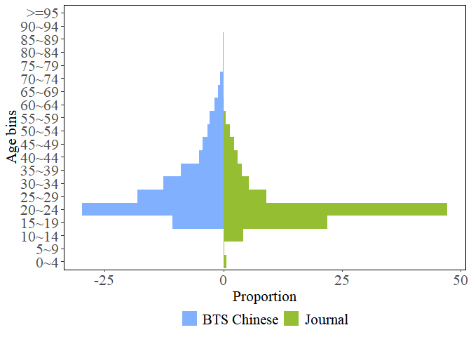

```r
H1_Fig_age_general <- ggplot(data= H1_age_general, aes(x=ageBins, y=ifelse(Data_Source=="BTS Chinese", -Proportion, Proportion),fill = Data_Source)) +
  geom_col(alpha=0.8, width = 1) +
  coord_flip() +
  labs(y="Proportion", x = "Age bins", color=NULL)+
  scale_fill_manual(values = c("BTS Chinese" = "#619CFF", "Journal" = "#7CAE00")) +
  theme_classic()+
  theme(panel.border =element_rect(fill=NA,color="black"),
        legend.position ="bottom",
        legend.box.spacing = unit(2,"pt"),
        legend.text = element_text(size = 16, family = "serif"),
        legend.title = element_blank(),
        axis.title = element_text(size = 16,family = "serif"),
        axis.text = element_text(size = 16,family = "serif"))


H1_Fig_age_general
```

Process age for Bayesian multinomial test. First of all, I processed BTS CHN age in psychological development stages.

```r
BTS_age_PsyStages_list <- list()

for(i in seq_along(BTS)){

  BTS_name <- names(BTS)[i]

  if("Age" %in% names(BTS[[i]])){

    BTS_age <- BTS[[i]] %>%
      dplyr::filter(!is.na(Age) & !is.na(ISO3)) %>%
      dplyr::mutate(Age = as.numeric(Age)) %>%
      dplyr::select(Article_Id,Age,Target_Population,ISO3) %>%
      dplyr::mutate(ageBins = cut(Age,
                                breaks = c(0, 17.5, 25.5, 40.5, 60.5, Inf),
                                labels = c("<=17","18~25","26~40", "41~60", ">=61"),
                                levels = c("<=17","18~25","26~40", "41~60", ">=61")))

BTS_age_PsyStages_list[[BTS_name]] <- BTS_age

} else {

    cat(sprintf("Skipping '%s' because it does not contain a 'Age' column.\n", BTS_name))
  }
}
```

```
## Skipping 'BTS_Atari_et_al_2020' because it does not contain a 'Age' column.
```

```r
## merge data.frame in list
BTS_age_PsyStages <-  do.call(rbind,BTS_age_PsyStages_list)
```

Secondly, I processed BTS CHN age in 10-year-old segment.

```r
BTS_age_interval10_list <- list()

for(i in seq_along(BTS)){

  BTS_name <- names(BTS)[i]

  if("Age" %in% names(BTS[[i]])){

    BTS_age <- BTS[[i]] %>%
      dplyr::filter(!is.na(Age) & !is.na(ISO3)) %>%
      dplyr::select(Article_Id,Age,Target_Population,ISO3) %>%
      dplyr::mutate(Age = as.numeric(Age)) %>%
      dplyr::mutate(ageBins = cut(Age,
                                breaks = c(0, 10.5, 20.5, 30.5, 40.5, 50.5, 60.5, Inf),
                                labels = c("<=10","11~20","21~30", "31~40", "41~50", "51~60", ">=61"),
                                levels = c("<=10","11~20","21~30", "31~40", "41~50", "51~60", ">=61")))

BTS_age_interval10_list[[BTS_name]] <- BTS_age

} else {

    cat(sprintf("Skipping '%s' because it does not contain a 'Age' column.\n", BTS_name))
  }
}
```

```
## Skipping 'BTS_Atari_et_al_2020' because it does not contain a 'Age' column.
```

```r
## merge data.frame in list
BTS_age_interval10 <-  do.call(rbind,BTS_age_interval10_list)
```

And then, I filtered BTS CHN data.

```r
## psychological development stages in BTS
### psychological development
BTS_age_PsyStages_CHN_general <- BTS_age_PsyStages %>%
  dplyr::filter(ISO3 == "CHN" & Target_Population != 1) %>%
  dplyr::count(ageBins) %>%
  dplyr::mutate(Proportion = n/sum(n)*100,
                Data_Source = "BTS Chinese")

sum(BTS_age_PsyStages_CHN_general$Proportion)
```

```
## [1] 100
```

```r
## 10-year-old segment in BTS
BTS_age_interval10_CHN_general <- BTS_age_interval10 %>%
  dplyr::filter(ISO3 == "CHN" & Target_Population != 1) %>%
  dplyr::select(1,5) %>%
  dplyr::count(ageBins) %>%
  dplyr::mutate(Proportion = n/sum(n)*100,
                Data_Source = "BTS Chinese")

sum(BTS_age_interval10_CHN_general$Proportion)
```

```
## [1] 100
```

Next, I Combined two CHN data to Bayesian multinomial test in two different classifications (PsyStages and 10-year-old). One is PsyStages.

```r
## general population
H1_PsyStages_bayes_general <- Sim_Journal_age_PsyStages3_general %>%
  dplyr::rename(n = 2) %>%
  dplyr::mutate(Proportion = n/sum(n)*100,
                Data_Source = "Journal") %>%
  bind_rows(BTS_age_PsyStages_CHN_general) %>%
  dplyr::select(-2) %>%
  tidyr::pivot_wider(names_from = Data_Source, values_from = Proportion)
## two data sum both 100 ##

H1_BF_PsyStages_general <- BayesMultiNomial(dataset = H1_PsyStages_bayes_general,
                                          factor = "ageBins",
                                          observed = "BTS Chinese",
                                          expected = "Journal")
```

For age (Psychological stages) with general population, there is difference between BTS and Chinese papers, $Log(BF_{10})$ = 27.9080385.

The other is interval10.

```r
## general population
H1_interval10_bayes_general <- Sim_Journal_age_interval103_general %>%
  dplyr::rename(n = 2) %>%
  dplyr::mutate(Proportion = n/sum(n)*100,
                Data_Source = "Journal") %>%
  bind_rows(BTS_age_interval10_CHN_general) %>%
  dplyr::select(-2) %>%
  tidyr::pivot_wider(names_from = Data_Source, values_from = Proportion)

# sum(H1_interval10_bayes_general$Journal)
# sum(H1_interval10_bayes_general$`BTS Chinese`)


H1_BF_interval10_general <- BayesMultiNomial(dataset = H1_interval10_bayes_general,
                                          factor = "ageBins",
                                          observed = "BTS Chinese",
                                          expected = "Journal")
```

I also found extremely strong evidence support $H_1$ for another age category,the Bayesian multinomial test shows $Log(BF_{10})$ = 14.3134473.

In addition, I attempt to conduct an exploratory analysis on Hypothesis 3 using four age groups (<18, 18~40, 41~60, >61). Therefore, I will save the following age data.

```r
save(Journal_age2,BTS,WEIRD,file = "H3_age_exploration.RData")
```

### attainment education

Try to process educational attainment data from Chinese journal.

```r
# Journal_edu <- Journal %>%
#   dplyr::filter(Educational_Attainment_N == 1) %>%
#   dplyr::select(Article_IDs,Study_Number,Subjects_Group,Sample_Size,M_age,SD_age,
#                 Educational_Attainment_info_N) %>%
#   dplyr::mutate(Higher_edu = NA,
#                 Below_higher_edu = NA,
#                 Compulsory_edu_above = NA,
#                 Compulsory_edu = NA ,
#                 M_edu_year = NA,
#                 SD_edu_year = NA)
#
# writexl::write_xlsx(Journal_edu,"Journal_edu.xlsx")


Journal_edu <- readxl::read_xlsx("Journal_edu.xlsx")


## analysis edu base on target population
## general population
Journal_edu_general_article <- Journal_key_variable %>%
  dplyr::select(Article_IDs,Target_Population_N) %>%
  dplyr::distinct(Article_IDs,Target_Population_N) %>%
  dplyr::filter(Target_Population_N != 1)


## filter target population is general population
Journal_edu_general <- Journal_edu %>%
  dplyr::filter(Article_IDs %in% Journal_edu_general_article$Article_IDs) %>%
  dplyr::mutate(Sample_Size = as.numeric(Sample_Size))

Journal_edu_general_papersnum <- Journal_edu_general %>%
  dplyr::distinct(Article_IDs)
```

In our study, educational attainment was categorized into three groups, and we processed the data for each group separately. The first group was defined by years of education, for which we reported the mean (M) and standard deviation (SD) in the paper. These descriptive statistics were then used to impute the sample sizes for the other two educational attainment groups (College and high school); subsequently, we merged the data of the first group with each of the latter two groups respectively, and finalized the subsequent analyses and data visualization.

```r
Journal_edu2_year <- Journal_edu_general %>%
  dplyr::select(1:15) %>%
  dplyr::filter(!is.na(M_edu_year) & !is.na(SD_edu_year)) %>%
  dplyr::filter(is.na(College_and_above))


## If there is data for the other two categories, there is no need to simulate using years of education, which is a screening done after looking at the data

## Simulation of education data based on normal distribution
College_threshold <- 12 ## The education years of college is set at 12
Highschool_threshold <- 9 ## The education years of high school is set at 9


## create a data.frame.
Journal_edu2_year_simul <- data.frame(Article_IDs = character(),
                      Study_Number = character(),
                      Subjects_Group = character(),
                      Sample_Size = integer(),
                      College_and_above = integer(),
                      Below_college = integer(),
                      High_school_and_above = integer(),
                      Below_high_school = integer())


# Calculate sample size for each educated stages
for (i in 1:nrow(Journal_edu2_year)) {
  Article_IDs = Journal_edu2_year$Article_IDs[i]
  Study_Number = Journal_edu2_year$Study_Number[i]
  Subjects_Group = Journal_edu2_year$Subjects_Group[i]
  Sample_Size <- Journal_edu2_year$Sample_Size[i]
  M_edu_year <- Journal_edu2_year$M_edu_year[i]
  SD_edu_year <- Journal_edu2_year$SD_edu_year[i]

# Use the cumulative distribution function to calculate the proportion of subjects below each threshold
  Prob_college_and_above <- pnorm(College_threshold, mean = M_edu_year, sd = SD_edu_year, lower.tail = FALSE)
  Prob_highschool_and_above <- pnorm(Highschool_threshold, mean = M_edu_year, sd = SD_edu_year, lower.tail = FALSE)

#Count people by proportion.
  College_and_above_count <- round(Sample_Size * Prob_college_and_above)
  College_below_count <- Sample_Size - College_and_above_count
  Highschool_and_above_count <- round(Sample_Size * Prob_highschool_and_above)
  Highschool_below_count <- Sample_Size - Highschool_and_above_count


# Adds the result to the data.frame
Journal_edu2_year_simul <- rbind(Journal_edu2_year_simul, data.frame(Article_IDs = Article_IDs,
                                       Study_Number = Study_Number,
                                       Subjects_Group = Subjects_Group,
                                       Sample_Size = Sample_Size,
                                       College_and_above = College_and_above_count,
                                       Below_college = College_below_count,
                                       High_school_and_above = Highschool_and_above_count,
                                       Below_high_school = Highschool_below_count))
}
```

The second category is ‘college and above’ and ‘below college’.

```r
Journal_college <- Journal_edu_general %>%
  dplyr::select(-c(5:9,12:15)) %>%
  dplyr::filter(!is.na(College_and_above) & !is.na(Below_college))

## paper num
Journal_college_papernum <- Journal_college %>%
  dplyr::distinct(Article_IDs)

##  both > 1
Journal_college_integer <- Journal_college  %>%
  dplyr::filter(College_and_above > 1 & Below_college > 1) %>%
  dplyr::summarise(College_and_above = sum(College_and_above),
                   Below_college = sum(Below_college))


## both < 1
Journal_college_decimal <- Journal_college  %>%
  dplyr::filter(College_and_above <= 1 & Below_college <= 1) %>%
  dplyr::mutate(Total_college_and_above = College_and_above + Below_college) %>%
  dplyr::mutate(College_and_above_tab = floor(Sample_Size * College_and_above),
                Below_college_tab = ifelse(Total_college_and_above == 1, Sample_Size - College_and_above_tab, floor(Sample_Size * Below_college))) %>%
  dplyr::mutate(tab = College_and_above_tab + Below_college_tab) %>%
  dplyr::summarise(College_and_above = sum(College_and_above_tab),
                   Below_college = sum(Below_college_tab))
```

The third category is ‘high shcool and above’ and ‘below high school’

```r
Journal_high_school <- Journal_edu_general %>%
  dplyr::select(4,12:13) %>%
  dplyr::filter(!is.na(High_school_and_above) & !is.na(Below_high_school))

## papers num
Journal_highschool_papernum <- Journal_edu_general %>%
  dplyr::filter(!is.na(High_school_and_above) & !is.na(Below_high_school)) %>%
  dplyr::distinct(Article_IDs)

##  both > 1
Journal_high_school_integer <- Journal_high_school %>%
  dplyr::filter(High_school_and_above > 1 & Below_high_school > 1) %>%
  dplyr::summarise(High_school_and_above = sum(High_school_and_above),
                   Below_high_school = sum(Below_high_school))

## both < 1
Journal_high_school_decimal <- Journal_high_school  %>%
  dplyr::filter(High_school_and_above <= 1 & Below_high_school <= 1) %>%
  dplyr::mutate(Total_High_school = High_school_and_above + Below_high_school) %>%
  dplyr::mutate(High_school_and_above_tab = floor(Sample_Size * High_school_and_above),
                Below_high_school_tab = ifelse(Total_High_school == 1, Sample_Size - High_school_and_above_tab, floor(Sample_Size * Below_high_school))) %>%
  dplyr::mutate(tab = High_school_and_above_tab + Below_high_school_tab) %>%
  dplyr::summarise(High_school_and_above = sum(High_school_and_above_tab),
                   Below_high_school = sum(Below_high_school_tab))
```

Combine education year with the other categories respectively.

```r
## combine college data
 Journal_college2 <-  bind_rows(Journal_college_decimal, Journal_college_integer) %>%
  dplyr::add_row(College_and_above = 1, Below_college = 141) %>%
  dplyr::summarise(College_and_above = sum(College_and_above),
                   Below_college = sum(Below_college)) %>%
  tidyr::pivot_longer(cols = c(College_and_above,Below_college),
                      names_to = "Educational_attainment",
                      values_to = "Num") %>%
  dplyr::mutate(Proportion = Num/sum(Num)*100,
                Data_source = "Journal")

sum(Journal_college2$Proportion)
```

```
## [1] 100
```

```r
## combine high school data
Journal_high_school2  <-   bind_rows(Journal_high_school_integer,
                                     Journal_high_school_decimal) %>%
  dplyr::add_row(High_school_and_above = 33, Below_high_school = 109) %>%
  dplyr::summarise(High_school_and_above = sum(High_school_and_above),
                   Below_high_school = sum(Below_high_school)) %>%
  tidyr::pivot_longer(cols = c(High_school_and_above,Below_high_school),
                      names_to = "Educational_attainment",
                      values_to = "Num") %>%
  dplyr::mutate(Proportion = Num/sum(Num)*100,
                Data_source = "Journal")

sum(Journal_high_school2$Proportion)
```

```
## [1] 100
```

Now, in this part, I process chinese subjects’ edu data of BTS

```r
# names(BTS_edu_list)
BTS_edu_list2 <- BTS_edu_list[names(BTS_edu_list) != "BTS_Hall_et_al_2018"]

BTS_edu_CHN <- lapply(BTS_edu_list2,function(df_edu){

  df_edu <- df_edu %>%
    dplyr::filter(ISO3 == "CHN")

  return(df_edu)
})

BTS_edu_CHN <- do.call(rbind,BTS_edu_CHN)
```

Classify educational attainment and calculate special num

```r
## calculate
BTS_college_CHN <- BTS_edu_CHN %>%
  dplyr::filter(!is.na(College)) %>%
  dplyr::group_by(College) %>%
  dplyr::summarise(n=n()) %>%
  dplyr::rename(Educational_attainment = 1, Num = 2) %>%
  dplyr::mutate(Proportion = Num/sum(Num)*100,
                Data_source = "BTS Chinese")

 sum(BTS_college_CHN$Proportion)
```

```
## [1] 100
```

```r
BTS_highschool_CHN <- BTS_edu_CHN %>%
  dplyr::filter(!is.na(Highschool)) %>%
  dplyr::group_by(Highschool) %>%
  dplyr::summarise(n=n()) %>%
  dplyr::rename(Educational_attainment = 1, Num = 2) %>%
  dplyr::mutate(Proportion = Num/sum(Num)*100,
                Data_source = "BTS Chinese")

sum(BTS_highschool_CHN$Proportion)
```

```
## [1] 100
```

```r
## Combine data
H1_edu_college <- rbind(Journal_college2,BTS_college_CHN)

H1_edu_highschool <- rbind(Journal_high_school2,BTS_highschool_CHN)


## set factor
H1_edu_college <- H1_edu_college %>%
  dplyr::mutate(Educational_attainment = ifelse(Educational_attainment == "Below_college",
                                                "Less-than-college","College-or-above"),
                Educational_attainment = factor(Educational_attainment,
                                                levels = c("College-or-above","Less-than-college")))


H1_edu_highschool <- H1_edu_highschool %>%
  dplyr::mutate(Educational_attainment = ifelse(Educational_attainment == "Below_high_school","Less-than-high-school","High-school-or-above"),
                Educational_attainment = factor(Educational_attainment,
                                                levels = c( "High-school-or-above",
                                                            "Less-than-high-school")))
```

visulize the edu data

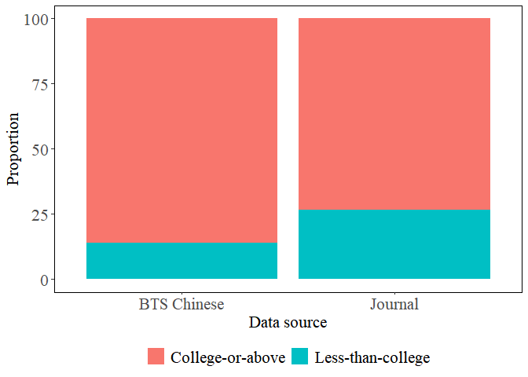

```r
## college
H1_Fig_college <- ggplot(data = H1_edu_college,aes(Data_source,Proportion,fill = Educational_attainment))+
  geom_col()+
  theme_classic()+
  theme(legend.position = "bottom",
        legend.text = element_text(size = 16, family = "serif"),
        legend.title = element_blank(),
        axis.title= element_text(size = 16,family = "serif"),
        axis.text = element_text(size = 16,family = "serif"),
        strip.text = element_text(size = 16,family = "serif"),
        strip.background = element_rect(fill = NA,color = NA),
        panel.border = element_rect(fill = NA,color = "black"))+
  xlab("Data source")

H1_Fig_college
```

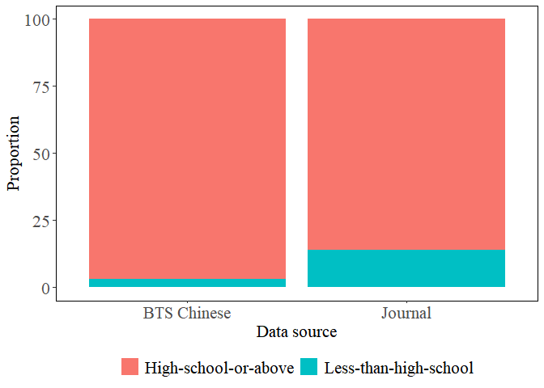

```r
## highschool
H1_Fig_highschool <- ggplot(data = H1_edu_highschool,aes(Data_source,Proportion,fill =Educational_attainment))+
  geom_col()+
  theme_classic()+
  theme(legend.position = "bottom",
        legend.text = element_text(size = 16, family = "serif"),
        legend.title = element_blank(),
        axis.title= element_text(size = 16,family = "serif"),
        axis.text = element_text(size = 16,family = "serif"),
        strip.text = element_text(size = 16,family = "serif"),
        strip.background = element_rect(fill = NA,color = NA),
        panel.border = element_rect(fill = NA,color = "black"))+
  xlab("Data source")

H1_Fig_highschool
```

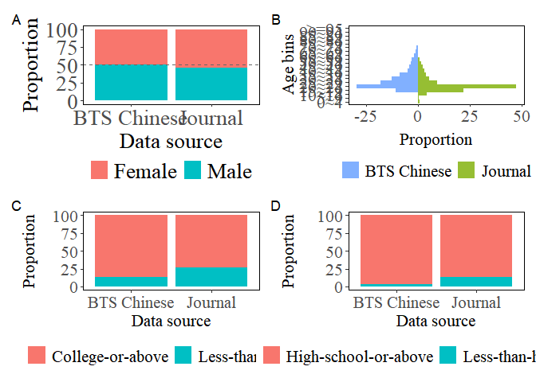

```r
H1_Fig_gender_age_edu_general <-  H1_Fig_gender_general + H1_Fig_age_general + H1_Fig_college + H1_Fig_highschool +
  plot_layout(ncol = 2, heights = c(4,4))+
  patchwork::plot_annotation(tag_levels = 'A')&
  theme(legend.position = 'bottom')

ggsave("H1_Fig_gender_age_edu_general.pdf",H1_Fig_gender_age_edu_general, device = "pdf", width=18, height = 18)

H1_Fig_gender_age_edu_general
```

Here I tested whether the educatinal attainment proportion distribution from Chinese five journal data are similar to that of the BTS data.

First, I calculate the first category: college.

```r
H1_edu_college_bayes <- H1_edu_college %>%
  dplyr::select(1,3:4) %>%
  tidyr::pivot_wider(names_from = Data_source, values_from = Proportion)


H1_BF_edu_college <- BayesMultiNomial(dataset = H1_edu_college_bayes,
                                      factor = "Educational_attainment",
                                      observed = "BTS Chinese",
                                      expected = "Journal")
```

I found moderate evidence for the $H_1$ that the college proportion from Chinese five journal data is different from that of BTS data, with $Log(BF_{10})$ = 2.2946748.

and then, I continue processing the second category: high school.

```r
H1_edu_highschool_bayes <- H1_edu_highschool %>%
  dplyr::select(1,3:4) %>%
  tidyr::pivot_wider(names_from = Data_source, values_from = Proportion)


H1_BF_edu_highschool <- BayesMultiNomial(dataset = H1_edu_highschool_bayes,
                                      factor = "Educational_attainment",
                                      observed = "BTS Chinese",
                                      expected = "Journal")
```

Similarity, I also found very strong evidence for the $H_1$ that the high schools proportion from Chinese five journal data is different from that of BTS data, with $Log(BF_{10})$ = 3.7883653.

## Test the 2nd hypothesis

For hypothesis 2, I first tried to analyze the data in general. I would then compare certain demographic characteristics of the Chinese subjects in studies (BTS and Chinese journals) with those corresponding to Census data or other representative large general social surveys (e.g., CFPS2018) based on the target population.

Firstly, I analyzed data in general.

### Gender

In this part, I processed gender data of the Census 6th, the Census 7th data, and the CFPS2018 data.

```r
## Process the gender data of census6
Census6_gender <- df_census6 %>%
  dplyr::select(6:7) %>%
  dplyr::slice(5)%>%
  dplyr::rename(Male=1,
                Female=2) %>%
  dplyr::mutate(Data_source = "Census6") %>%
  tidyr::pivot_longer(c(Male, Female),
                      names_to = "Gender",
                      values_to = "Proportion") %>%
  dplyr::mutate(Proportion = as.numeric(Proportion))


## Process the gender data of census 7
Census7_gender <- df_census7 %>%
  dplyr::select(c(6,7)) %>%
  dplyr::slice(c(6)) %>%
  dplyr::rename(Male=1,
                Female=2) %>%
  dplyr::mutate(Data_source = "Census7") %>%
  tidyr::pivot_longer(c(Male, Female),
                      names_to = "Gender",
                      values_to = "Proportion") %>%
  dplyr::mutate(Proportion = as.numeric(Proportion))


## Process the gender data of CFPS2018
CFPS2018_gender <- df_CFPS2018 %>%
  dplyr::rename(Gender = QA002) %>%
  dplyr::count(Gender) %>%
  dplyr::filter(!is.na(Gender)) %>%
  dplyr::mutate(Proportion = n / sum(n)*100,
                Data_source = "CFPS2018",
                Gender= ifelse(Gender == 1, "Male", "Female")) %>%
  dplyr::select(Data_source, Gender, Proportion)

sum(CFPS2018_gender$Proportion)
```

```
## [1] 100
```

Secondly, I converted data format and combined three data sources.

```r
## Convert H1_gender data format
H1_gender_general2 <- H1_gender_general %>%
  dplyr::select(1:2) %>%
  dplyr::group_by(Gender) %>%
  dplyr::summarise(n = sum(n)) %>%
  dplyr::mutate(Proportion = n/sum(n)*100,
                Data_source = "Chinese participants") %>%
  dplyr::ungroup()

sum(H1_gender_general2$Proportion)
```

```
## [1] 100
```

```r
H2_gender_general <- bind_rows(Census7_gender,CFPS2018_gender,H1_gender_general2)
```

And then, I combined all Chinese gender data and visualized them.

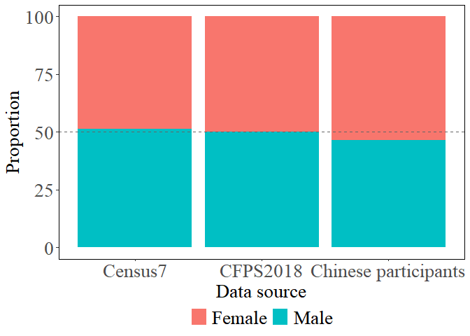

```r
H2_Fig_gender_general <- ggplot(H2_gender_general,aes(Data_source,Proportion,fill= Gender))+
  geom_col()+
  geom_hline(yintercept = 50, linetype = "dashed", color = "#666666")+
  labs(y="Proportion",x = "Data source")+
  theme_classic()+
  theme(panel.border =element_rect(fill=NA,color="black"),
        legend.position = "bottom",
        legend.box.spacing = unit(2,"pt"),
        legend.text = element_text(size = 20, family = "serif"),
        legend.title = element_blank(),
        axis.title = element_text(size = 20,family = "serif"),
        axis.text = element_text(size = 20,family = "serif"))


H2_Fig_gender_general
```

Finally, I calculated the bayes factor for gender.

```r
## general population
H2_gender_bayes_general <- H2_gender_general %>%
  dplyr::select(2,3,1) %>%
  tidyr::pivot_wider(names_from = Data_source,values_from = Proportion)


H2_BF_gender_Census7_general <- BayesMultiNomial(dataset = H2_gender_bayes_general,
                                          factor = "Gender",
                                          observed = "Chinese participants",
                                          expected = "Census7")


H2_BF_gender_CFPS2018_general <- BayesMultiNomial(dataset = H2_gender_bayes_general,
                                          factor = "Gender",
                                          observed = "Chinese participants",
                                          expected = "CFPS2018")
```

The calculation results show that there is no difference between the data in Chinese participants and Census7 and CFPS2018, and the calculation results are: Census7 VS Chinese participants: $Log(BF_{10})$ = -1.6448112 , CFPS2018 VS Chinese participants: $Log(BF_{10})$ = -1.8380376

save gender data for exploration analyse

```r
save(H1_gender_general,H2_gender_general,Census6_gender,file = "H2_gender_exploration.Rdata") ## data include papers, projects, and Census data.
```

In this part, I calculate data based on special target population I calculate preschool children.

```r
Journal_gender_preschool <- Journal_gender_Infants_toddlers_TP_IDs %>%
  dplyr::summarise(Male_Num = sum(as.numeric(Male_Num)), ## 3832
                   Female_Num = sum(as.numeric(Female_Num))) ## 3598

H2_gender_preschool_special <- data.frame(Gender = c("Female","Male","Female","Male"),
                                          n = c(3598,3832,40,53),
                                          Data_source = c("Journal","Journal","Lucca","Lucca"))


## calculate Prop
H2_gender_preschool_special_prop <- H2_gender_preschool_special %>%
  dplyr::group_by(Gender) %>%
  dplyr::summarise(n=sum(n)) %>%
  dplyr::mutate(Proportion = n/sum(n)*100,
                 Data_source = "Chinese participants")

# sum(H2_gender_preschool_special_prop$Proportion) ## 100
# sum(H2_gender_preschool_special$n) ## 7523


## Census7th preschool (under 6 years old)
Census7_gender_preschool_special <- df_census7 %>%
  dplyr::select(1,3,4) %>%
  dplyr::slice(c(9:13,16:17)) %>%
  dplyr::rename(Age = 1, Male = 2, Female = 3) %>%
  dplyr::summarise(Male = sum(as.numeric(Male)),
                   Female = sum(as.numeric(Female))) %>%
  pivot_longer(cols = c("Male","Female"),
               names_to = "Gender",
               values_to = "n") %>%
  dplyr::mutate(Proportion = n/sum(n)*100,
                Data_source = "Census7")

# sum(Census7_gender_preschool_special$Proportion) ## 100


## combine tow data
H2_gender_preschool_bayes_special <- bind_rows(H2_gender_preschool_special_prop,
                                         Census7_gender_preschool_special) %>%
  dplyr::select(1,3:4) %>%
  tidyr::pivot_wider(names_from = Data_source, values_from = Proportion)



## bayes
H2_BF_gender_preschool_Census <- BayesMultiNomial(dataset = H2_gender_preschool_bayes_special,
                                                factor = "Gender",
                                                observed = "Chinese participants",
                                                expected = "Census7")
```

I calculate college

```r
Journal_college_TP_IDs <-  Journal_college_TP %>%
  dplyr::pull(Article_IDs)

Journal_gender_college_sepcial <-  Journal %>%
  dplyr::filter(Article_IDs_N %in% Journal_college_TP_IDs) %>%
  dplyr::select(Article_IDs_N,Article_Title,Study_Number,Subjects_Group_N,
                Gender,Male_Num,Female_Num,Sample_Size,
                Sample_Type_N) %>%
  dplyr::filter(Gender == 1) %>%
  dplyr::mutate(Male_Num = as.numeric(Male_Num),
                Sample_Size = as.numeric(Sample_Size),
                Female_Num = as.numeric(Female_Num),
                Male_Num = ifelse(Male_Num < 1 & Female_Num < 1,
                                  floor(Male_Num * Sample_Size),Male_Num),
                Female_Num = ifelse(Female_Num < 1 & Female_Num > 0,
                                    Sample_Size - Male_Num,Female_Num))


Journal_gender_college_sepcial2 <- Journal_gender_college_sepcial %>%
  dplyr::summarise(Male =sum(Male_Num),
                   Female = sum(Female_Num)) %>%
  tidyr::pivot_longer(cols = c("Male","Female"),
                      names_to = "Gender",
                      values_to = "n") %>%
  dplyr::mutate(Proportion = n/sum(n)*100)

sum(Journal_gender_college_sepcial2$Proportion)
```

```
## [1] 100
```

```r
## The total data we compared is from *the Outline for Women's Development in China (2021-2030)* released by the National Bureau of Statistics of China in 2022. website:https://www.stats.gov.cn/sj/zxfb/202312/t20231229_1946062.html

H2_gender_college_bayes_special <- data.frame(Gender = c("Male","Female"),
                                              Journal = c(45.4552,54.5448),
                                              Outline_Women = c(50,50))

H2_BF_gender_college_special <- BayesMultiNomial(dataset = H2_gender_college_bayes_special,
                                                 factor = "Gender",
                                                 observed = "Journal",
                                                 expected = "Outline_Women")
```

In terms of gender, for the special target population of college students, we have found that there is no difference between Journal and the overall data of China (the Outline for Women’s Development in China (2021-2030)), $Log(BF_{10})$ = -1.6746897.

### Age

Similarly, for age data, I first processed the Census data and the CFPS2018 data.

```r
## Process age data of the census 6
Census6_age_five5 <- df_census6 %>%
  dplyr::filter(row_number() %% 6 == 0) %>%
  dplyr::select(1,2,5) %>%
  dplyr::rename(ageBins = 1, Proportion = 3) %>%
  dplyr::mutate(Proportion = as.numeric(Proportion)) %>%
  dplyr::mutate(ageBins = str_remove(ageBins, "岁")) %>%
  dplyr::mutate(ageBins = str_replace_all(ageBins, "-", "~")) %>%
  dplyr::slice(-21)

Census6_age_five5$ageBins[20] <- ">=95"

Census6_age_five5 <- Census6_age_five5 %>%
  dplyr::group_by(ageBins) %>%
  dplyr::summarise(Proportion = sum(Proportion)) %>%
  dplyr::mutate(Data_Source = "Census6") %>%
  dplyr::ungroup() %>%
  dplyr::arrange(ageBins) %>%
  dplyr::mutate(ageBins = factor(ageBins,
                                 levels =c("0~4","5~9","10~14","15~19","20~24",
                                 "25~29","30~34","35~39","40~44","45~49",
                                 "50~54","55~59","60~64","65~69","70~74",
                                 "75~79","80~84","85~89", "90~94",">=95" )))

## Process age data of the census 7
Census7_age_five5 <- df_census7 %>%
  dplyr::rename(ageBins = 1,n = 2,Proportion = 5) %>%
  dplyr::filter(str_detect(ageBins,"岁")) %>%
  dplyr::select(1,2,5) %>%
  dplyr::mutate(Proportion = as.numeric(Proportion)) %>%
  dplyr::mutate(ageBins = str_remove(ageBins, "岁")) %>%
  dplyr::mutate(ageBins = str_replace_all(ageBins, "-", "~")) %>%
  dplyr::slice(-21)

Census7_age_five5$ageBins[20] <- ">=95"
Census7_age_five5$Proportion[20] <- 0.06+0.01


Census7_age_five5 <- Census7_age_five5 %>%
  dplyr::group_by(ageBins) %>%
  dplyr::summarise(Proportion = sum(Proportion)) %>%
  dplyr::mutate(Data_Source = "Census7") %>%
  dplyr::ungroup() %>%
  dplyr::mutate(ageBins = factor(ageBins,
                                 levels =c("0~4","5~9","10~14","15~19","20~24",
                                 "25~29","30~34","35~39","40~44","45~49",
                                 "50~54","55~59","60~64","65~69","70~74",
                                 "75~79","80~84","85~89", "90~94",">=95" )))

# sum(Census7_age_five5$Proportion) 100.02
```

Then, I convert the data format of H1_age.

```r
H2_age_general <- H1_age_general %>%
  dplyr::select(1:2) %>%
  dplyr::group_by(ageBins) %>%
  dplyr::summarise(n = sum(n)) %>%
  dplyr::mutate(Proportion = n/sum(n)*100) %>%
  dplyr::ungroup()

sum(H2_age_general$Proportion)
```

```
## [1] 100
```

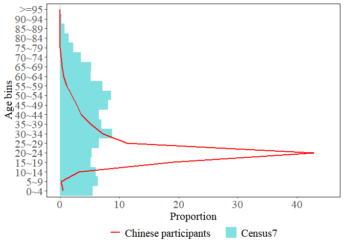

```r
H2_Fig_age_general <- ggplot(data= Census7_age_five5,
       aes(x=ageBins, y = Proportion, fill="Census7")) +
  geom_col(alpha=0.5, width = 1) +
  geom_line(data = H2_age_general, aes(x=ageBins,
                y = Proportion,group = 1,color = "Chinese participants"),size =1)+
  scale_fill_manual(values=c("Census7"="#00BFC4")) +
  scale_color_manual(values=c("Chinese participants" = "red")) +
  scale_y_continuous(limits = c(0,45))+
  coord_flip() +
  labs(y="Proportion", x = "Age bins")+
  theme_classic()+
  theme(panel.border =element_rect(fill=NA,color="black"),
        legend.position = "bottom",
        legend.box.spacing = unit(2,"pt"),
        legend.text = element_text(size = 16, family = "serif"),
        legend.title = element_blank(),
        axis.title = element_text(size = 16,family = "serif"),
        axis.text = element_text(size = 16,family = "serif"))
H2_Fig_age_general
```

In addition, I calculated the bayes factor. process the data of Census 6th for exploration analyse.

```r
Census6_age <- df_census6 %>%
  dplyr::rename(Age = 1, n = 2) %>%
  dplyr::select(Age,n) %>%
  dplyr::slice(7:126) %>%  ## select agebins rows
  dplyr::filter(!grepl("岁",Age)) %>%
  dplyr::mutate(Age = as.numeric(Age),
                n = as.numeric(n),
                n = ifelse(Age == "99",n+35934,n))  ## include 100 years old and above


## PsyStages
Census6_age_PsyStages <- Census6_age %>%
  dplyr::mutate(ageBins = cut(Age,
                                breaks = c(-Inf, 17.5, 25.5, 40.5, 60.5, Inf),
                                labels = c("<=17","18~25","26~40", "41~60", ">=61"),
                                levels = c("<=17","18~25","26~40", "41~60", ">=61"))) %>%
  dplyr::group_by(ageBins) %>%
  dplyr::summarise(n = sum(n)) %>%
  dplyr::mutate(Proportion = n/sum(n)*100) %>%
  dplyr::ungroup() %>%
  dplyr::mutate(Data_Source = "Census6")

sum(Census6_age_PsyStages$Proportion)
```

```
## [1] 100
```

```r
## interval10
Census6_age_interval10 <- Census6_age %>%
  dplyr::mutate(ageBins = cut(Age,
                              breaks = c(-Inf, 10.5, 20.5, 30.5, 40.5, 50.5, 60.5, Inf),
                              labels = c("<=10","11~20","21~30", "31~40", "41~50", "51~60", ">=61"),
                              levels = c("<=10","11~20","21~30", "31~40", "41~50", "51~60", ">=61"))) %>%
  dplyr::group_by(ageBins) %>%
  dplyr::summarise(n = sum(n)) %>%
  dplyr::mutate(Proportion = n/sum(n)*100) %>%
  dplyr::ungroup() %>%
  dplyr::mutate(Data_Source = "Census6")

sum(Census6_age_interval10$Proportion)
```

```
## [1] 100
```

```r
# Firstly, I process Census data for the following analysis.
## process census data.
Census7_age <- df_census7 %>%
  dplyr::rename(ageBins = 1, n = 2) %>%
  dplyr::slice(9:145) %>%
  dplyr::filter(ageBins != "" & !grepl("岁",ageBins)) %>%
  dplyr::select(1,2) %>%
  dplyr::mutate_at(vars(1:2),as.numeric) %>%
  dplyr::mutate(n = ifelse(ageBins == "99", n+118866,n))  ## include 100 years old and above

## PsyStages
Census7_age_PsyStages <- Census7_age %>%
  dplyr::mutate(ageBins = cut(ageBins,
                                breaks = c(-Inf, 17.5, 25.5, 40.5, 60.5, Inf),
                                labels = c("<=17","18~25","26~40", "41~60", ">=61"),
                                levels = c("<=17","18~25","26~40", "41~60", ">=61"))) %>%
  dplyr::group_by(ageBins) %>%
  dplyr::summarise(n = sum(n)) %>%
  dplyr::mutate(Proportion = n/sum(n)*100) %>%
  dplyr::ungroup() %>%
  dplyr::mutate(Data_Source = "Census7")

sum(Census7_age_PsyStages$Proportion)
```

```
## [1] 100
```

```r
## interval10
Census7_age_interval10 <- Census7_age %>%
  dplyr::mutate(ageBins = cut(ageBins,
                              breaks = c(-Inf, 10.5, 20.5, 30.5, 40.5, 50.5, 60.5, Inf),
                              labels = c("<=10","11~20","21~30", "31~40", "41~50", "51~60", ">=61"),
                              levels = c("<=10","11~20","21~30", "31~40", "41~50", "51~60", ">=61"))) %>%
  dplyr::group_by(ageBins) %>%
  dplyr::summarise(n = sum(n)) %>%
  dplyr::mutate(Proportion = n/sum(n)*100) %>%
  dplyr::ungroup() %>%
  dplyr::mutate(Data_Source = "Census7")

sum(Census7_age_PsyStages$Proportion)
```

```
## [1] 100
```

```r
## For target population, I need combine two source data firstly.
## PsySatges
Sim_Journal_age_PsyStages3_general_prop <- Sim_Journal_age_PsyStages3_general %>%
  dplyr::rename(n =2)


H2_age_Psystages_bayes_general <- bind_rows(BTS_age_PsyStages_CHN_general,Sim_Journal_age_PsyStages3_general_prop) %>%
  dplyr::select(1:2) %>%
  dplyr::group_by(ageBins) %>%
  dplyr::summarise(n = sum(n)) %>%
  dplyr::mutate(Proportion = n/sum(n)*100,
                Data_Source = "Chinese participants") %>%
  dplyr::add_row(Census7_age_PsyStages) %>%
  dplyr::select(-2) %>%
  tidyr::pivot_wider(names_from = Data_Source,values_from = Proportion)

sum(H2_age_Psystages_bayes_general$`Chinese participants`)
```

```
## [1] 100
```

```r
## interval10
Sim_Journal_age_interval103_general_prop <-  Sim_Journal_age_interval103_general %>%
  dplyr::rename(n = 2)

H2_age_inteval10_bayes_general <- bind_rows(BTS_age_interval10_CHN_general,Sim_Journal_age_interval103_general_prop) %>%
  dplyr::select(1:2) %>%
  dplyr::group_by(ageBins) %>%
  dplyr::summarise(n = sum(n)) %>%
  dplyr::mutate(Proportion = n/sum(n)*100,
                Data_Source = "Chinese participants") %>%
  dplyr::add_row(Census7_age_interval10) %>%
  dplyr::select(-2) %>%
  tidyr::pivot_wider(names_from = Data_Source,values_from = Proportion)

sum(H2_age_inteval10_bayes_general$`Chinese participants`)
```

```
## [1] 100
```

```r
## calculate bayes factor
H2_BF_age_Psystages_general <- BayesMultiNomial(dataset = H2_age_Psystages_bayes_general,
                              factor = "ageBins",
                              observed = "Chinese participants",
                              expected = "Census7")


H2_BF_age_interval10_general <- BayesMultiNomial(dataset = H2_age_inteval10_bayes_general,
                              factor = "ageBins",
                              observed = "Chinese participants",
                              expected = "Census7")
```

For age within general population, I found the Bayesian multinomial test shows extremely strong evidence in foavor of $H_1$. PsyStages and interval10 are $Log(BF_{10})$ = 86.0471969 and interval10: $Log(BF_{10})$ = 63.4497376 respectively.

### Educational attainment

Load and process the edu data of census 7th

```r
Census7_edu <- readxl::read_xls("A0401.xls")
Census7_edu_adults <- Census7_edu %>%
  dplyr::slice(c(3,4,29,30,32,39,46,53,60,67,74,81,88,95,102,109,116,123)) %>%
  dplyr::select(1,2,5,8,11,14,17,20,23,26,29) %>%
  dplyr::rename(Age = 1,Three_years_old_above = 2, Never_attended_school = 3,
                Preschool_education = 4,Primary_school = 5,Middle_school = 6,
                High_school = 7, Junior_college = 8, Undergraduate_education = 9,
                Postgraduate_student = 10,Doctoral_student = 11) %>%
  dplyr::slice(-c(1:2)) %>%
  dplyr::mutate(across(-1,as.numeric))


Census7_college <- Census7_edu_adults %>%
  dplyr::summarise(`Less-than-college` = sum(across(3:7)),
                   `College-or-above` = sum(across(8:11))) %>%
  tidyr::pivot_longer(cols = c(1,2),
                      names_to = "Educational_attainment",
                      values_to = "Num") %>%
  dplyr::mutate(Proportion = Num/sum(Num)*100,
                Data_source = "Census7")

sum(Census7_college$Proportion)
```

```
## [1] 100
```

```r
Census7_high_school <- Census7_edu_adults %>%
  dplyr::summarise(`Less-than-high-school` = sum(across(3:6)),
                   `High-school-or-above` = sum(across(7:11))) %>%
  tidyr::pivot_longer(cols = c(1,2),
                      names_to = "Educational_attainment",
                      values_to = "Num") %>%
  dplyr::mutate(Proportion = Num/sum(Num)*100,
                Data_source = "Census7")

sum(Census7_high_school$Proportion)
```

```
## [1] 100
```

receive edu data of CFPS2018

```r
CFPS2018_edu <- df_CFPS2018 %>%
  dplyr::filter(W01 > -1) %>%
  dplyr::group_by(W01) %>%
  dplyr::summarise(Num = n()) %>%
  dplyr::ungroup() %>%
  dplyr::mutate(W01 = as.character(W01)) %>%
  dplyr::mutate(W01 = case_when(W01 == 0 ~ "Illiterate/Semi - illiterate",
                                W01 == 3 ~ "Primary school",
                                W01 == 4 ~ "high school",
                                W01 == 5 ~ "Senior high school/Secondary vocational school/Technical school/Vocational high school",
                                W01 == 6 ~ "Junior college",
                                W01 == 7 ~ "Undergraduate_education",
                                W01 == 8 ~ "Postgraduate_student",
                                W01 == 9 ~ "Doctoral_student",
                                W01 == 10 ~ "Never attended school",
                                TRUE ~ W01))


CFPS2018_edu_college <- data.frame(Educational_attainment = c("Less-than-college","College-or-above"),
                                   Num = c(2846+756+3598+5273,3058+1648+1335+112+7)) %>%
  dplyr::mutate(Proportion = Num/sum(Num)*100,
                Data_source = "CFPS2018")

sum(CFPS2018_edu_college$Proportion)
```

```
## [1] 100
```

```r
CFPS2018_edu_high_school <- data.frame(Educational_attainment = c("Less-than-high-school","High-school-or-above"),
                                   Num = c(2846+756+3598+5273+3058,1648+1335+112+7)) %>%
  dplyr::mutate(Proportion = Num/sum(Num)*100,
                Data_source = "CFPS2018")


sum(CFPS2018_edu_high_school$Proportion)
```

```
## [1] 100
```

Combine multiple edu data

```r
## College
Chinese_subjects_pools_edu_college <- H1_edu_college %>%
  dplyr::select(-3) %>%
  dplyr::group_by(Educational_attainment) %>%
  dplyr::summarise(Num = sum(Num)) %>%
  dplyr::ungroup() %>%
  dplyr::mutate(Proportion = Num/sum(Num)*100,
                Data_source = "Chinese participants")

sum(Chinese_subjects_pools_edu_college$Proportion)
```

```
## [1] 100
```

```r
H2_edu_college <- bind_rows(Chinese_subjects_pools_edu_college,
                            Census7_college,CFPS2018_edu_college)


## highschool
Chinese_subjects_pools_edu_highschool <- H1_edu_highschool %>%
  dplyr::select(-3) %>%
  dplyr::group_by(Educational_attainment) %>%
  dplyr::summarise(Num = sum(Num)) %>%
  dplyr::ungroup() %>%
  dplyr::mutate(Proportion = Num/sum(Num)*100,
                Data_source = "Chinese participants")

sum(Chinese_subjects_pools_edu_highschool$Proportion)
```

```
## [1] 100
```

```r
H2_edu_highschool <- bind_rows(Chinese_subjects_pools_edu_highschool,
                               Census7_high_school,CFPS2018_edu_high_school)  %>%
  dplyr::mutate(Data_source = factor(Data_source,
                                     levels = c("Census7","CFPS2018","Chinese participants")))
```

And visualization

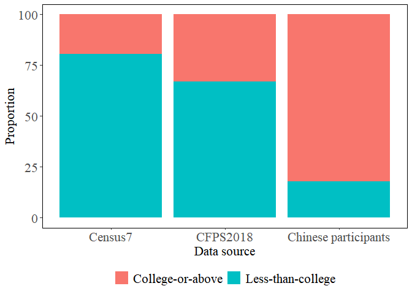

```r
## college
H2_Fig_college <- ggplot(data = H2_edu_college,aes(Data_source,Proportion,fill = Educational_attainment))+
  geom_col()+
  xlab("Data source")+
  theme_classic()+

  scale_fill_manual(values = c("Less-than-college" = "#00BFC4", "College-or-above" = "#F8766D")) +
  theme(legend.position = "bottom",
        legend.text = element_text(size = 16, family = "serif"),
        legend.title = element_blank(),
        axis.title= element_text(size = 16,family = "serif"),
        axis.text = element_text(size = 16,family = "serif"),
        strip.text = element_text(size = 16,family = "serif"),
        strip.background = element_rect(fill = NA,color = NA),
        panel.border = element_rect(fill = NA,color = "black"))

H2_Fig_college
```

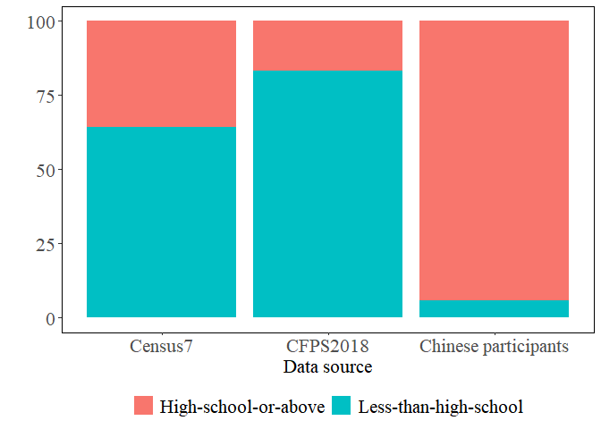

```r
## high school
H2_Fig_highschool <- ggplot(data = H2_edu_highschool,aes(Data_source,Proportion,fill = Educational_attainment))+
  geom_col()+
  theme_classic()+
  ylab("")+
  xlab("Data source")+

  scale_fill_manual(values = c("Less-than-high-school" = "#00BFC4", "High-school-or-above" = "#F8766D")) +
  theme(legend.position = "bottom",
        legend.text = element_text(size = 16, family = "serif"),
        legend.title = element_blank(),
        axis.title= element_text(size = 16,family = "serif"),
        axis.text = element_text(size = 16,family = "serif"),
        strip.text = element_text(size = 16,family = "serif"),
        strip.background = element_rect(fill = NA,color = NA),
        panel.border = element_rect(fill = NA,color = "black"))

H2_Fig_highschool
```

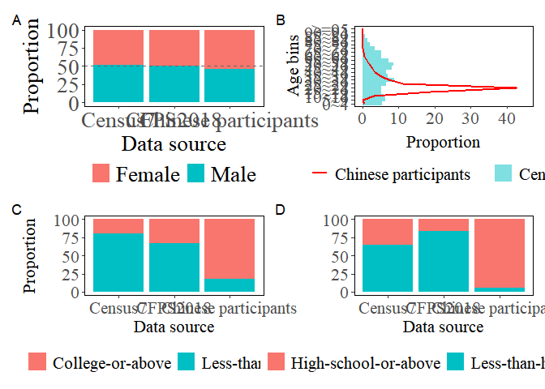

```r
## combine Fig

H2_Fig_gender_age_edu_general <- H2_Fig_gender_general + H2_Fig_age_general +H2_Fig_college + H2_Fig_highschool +
  plot_layout(ncol = 2, heights = c(4,4))+
  patchwork::plot_annotation(tag_levels = 'A')

ggsave("H2_Fig_gender_age_edu_general.pdf",H2_Fig_gender_age_edu_general, device = "pdf", width=18, height = 18)

H2_Fig_gender_age_edu_general
```

Calculate the BF of edu

```r
## college
H2_edu_college_bayes <- H2_edu_college %>%
  dplyr::select(1,3:4) %>%
  tidyr::pivot_wider(names_from = Data_source, values_from = Proportion)

H2_BF_edu_college_Census7 <- BayesMultiNomial(dataset = H2_edu_college_bayes,
                                          factor = "Educational_attainment",
                                          observed = "Chinese participants",
                                          expected = "Census7")


H2_BF_edu_college_CFPS2018 <- BayesMultiNomial(dataset = H2_edu_college_bayes,
                                          factor = "Educational_attainment",
                                          observed = "Chinese participants",
                                          expected = "CFPS2018")



## high school
H2_edu_highschool_bayes <- H2_edu_highschool %>%
  dplyr::select(1,3:4) %>%
  tidyr::pivot_wider(names_from = Data_source, values_from = Proportion)

H2_BF_edu_highschool_Census7 <- BayesMultiNomial(dataset = H2_edu_highschool_bayes,
                                          factor = "Educational_attainment",
                                          observed = "Chinese participants",
                                          expected = "Census7")


H2_BF_edu_highschool_CFPS2018 <- BayesMultiNomial(dataset = H2_edu_highschool_bayes,
                                          factor = "Educational_attainment",
                                          observed = "Chinese participants",
                                          expected = "CFPS2018")
```

I found all results show extremely evidence support $H_1$.

Save the data so that I can compare the data from large-scale international cooperation projects and Chinese journals respectively with the census data and data from CFPS.

```r
save(H1_age_general,H1_PsyStages_bayes_general,H1_interval10_bayes_general,
     H1_edu_college_bayes,H1_edu_highschool_bayes,
     H2_edu_college_bayes,H2_edu_highschool_bayes,
     Census7_age_five5,Census7_age_interval10,Census7_age_PsyStages,
     Census6_age_five5,Census6_age_PsyStages,Census6_age_interval10,
     Census7_high_school,Census7_college,CFPS2018_edu_high_school,CFPS2018_edu_college,
     file = "H2_BTS_Journal_age_edu.RData")
```

### Region

As stated in RR stage1, I tried to analysis region data. As a first step, I processed Subjects_Recruitment_Area data from Chinese journals.

Create a vector of China’s four economic regions, with data sourced from the National Bureau of Statistics of China. The four regions are Central, Eastern, Western, and Northeastern.

```r
Central_China4 <- c("山西","安徽","江西","河南","湖北","湖南")

East_China4 <- c("北京","天津","河北","上海","江苏","浙江","福建","山东","广东","海南")

West_China4 <- c("内蒙古","广西","重庆","四川","贵州","云南","西藏","陕西","甘肃","青海","宁夏","新疆")

Northeast_China4 <- c("辽宁","吉林","黑龙江")

China_region_four <- tibble(Region = c(Central_China4, East_China4,
                                        West_China4, Northeast_China4),
                             Region_four = c(rep("Central China", 6), rep("East China", 10),
                                        rep("West China", 12),rep("Northeast China", 3)))
```

We also create a vector of China’s seven regions.

```r
China_region_seven <-  tibble(
  Region = c("北京", "天津", "河北", "山西", "内蒙古",
              "上海", "江苏", "浙江", "安徽", "福建", "江西", "山东",
              "河南", "湖北", "湖南",
              "广东", "广西", "海南",
              "重庆", "四川", "贵州", "云南", "西藏",
              "陕西", "甘肃", "青海", "宁夏", "新疆",
              "辽宁", "吉林", "黑龙江"),
  Region_seven = c(rep("North China", 5),
             rep("East China", 7),
             rep("Central China", 3),
             rep("South China", 3),
             rep("Southwest China", 5),
             rep("Northwest China", 5),
             rep("Northeast China", 3)))
```

Create a vector of all China’ province

```r
China_province <- c("新疆","西藏","甘肃","青海","内蒙古",
                    "宁夏","四川","重庆","陕西","贵州","云南",
                    "北京","山西","河北","河南","湖北","湖南",
                    "广西","广东","香港","澳门","台湾","海南",
                    "黑龙江","吉林","辽宁","天津","山东","江苏",
                    "安徽","上海","浙江","江西","福建")
```

The data is processed when the target population is the general population.

single region

```r
Journal_region_single <- Journal %>%
   dplyr::select(3,5,7,37,40,16,30) %>%
   dplyr::mutate(Subjects_Recruitment_Area = gsub("[;；、，,]",";",Subjects_Recruitment_Area),
                 Sample_Size = as.numeric(Sample_Size)) %>%
   dplyr::filter(Subjects_Recruitment_Area != "0" & !grepl(";",Subjects_Recruitment_Area)) %>%
  dplyr::filter(Target_Population_N != 1)

## Article 20185082' Sample_Size became NA during data format conversion, but it does not affect the results as it is unrelated to the target population(special population).

 ## papers
Journal_region_single_papers_num <- Journal_region_single %>%
   dplyr::filter(Subjects_Recruitment_Area %in% China_province) %>%
   dplyr::distinct(Article_IDs) ## single 129 papers + multiple 11(only one targeting general population) = 522


Journal_region_single_general_tab <- Journal_region_single %>%
   dplyr::select(Article_IDs,Target_Population_N,Sample_Size,Subjects_Recruitment_Area) %>%
   dplyr::mutate(Subjects_Recruitment_Area = ifelse(Subjects_Recruitment_Area == "内蒙古自治区", "内蒙古",Subjects_Recruitment_Area),
                 Subjects_Recruitment_Area = ifelse(Subjects_Recruitment_Area == "广州","广东",Subjects_Recruitment_Area)) %>%
   dplyr::filter(Subjects_Recruitment_Area %in% China_province) %>%
   dplyr::group_by(Subjects_Recruitment_Area) %>%
   dplyr::summarise(n = sum(Sample_Size))
```

multiple regions

```r
# Journal_region_multiple <- Journal %>%
#    dplyr::select(3,5,7,37,40,16,30) %>%
#    dplyr::mutate(Subjects_Recruitment_Area = gsub("[;；、，,]",";",Subjects_Recruitment_Area)) %>%
#    dplyr::filter(Subjects_Recruitment_Area != "0" & grepl(";",Subjects_Recruitment_Area))

 # writexl::write_xlsx(Journal_region_multiple,"Journal_region_multiple.xlsx")

 ## re-input data and load data
 Journal_region_multiple <- readxl::read_xlsx("Journal_region_multiple.xlsx") %>%
   dplyr::filter(True_Value != "No specific value")



Journal_region_multiple_general_tab <-   Journal_region_multiple %>%
  dplyr::select(Article_IDs, Target_Population_N,True_Value) %>%
  dplyr::filter(Target_Population_N != 1) %>%
  tidyr::separate_rows(True_Value,sep = ";") %>%
  tidyr::separate(True_Value,c("Subjects_Recruitment_Area","Sample_Size"),sep = ":") %>%
   dplyr::filter(Subjects_Recruitment_Area %in% China_province) %>%
  dplyr::mutate(Sample_Size  = as.numeric(Sample_Size),
                Sample_Size = ifelse(Article_IDs == "20213104",ceiling(Sample_Size*2500),Sample_Size)) %>%
  dplyr::select(Sample_Size,Subjects_Recruitment_Area) %>%
  dplyr::rename(n = Sample_Size)
```

combine two data

```r
Journal_region_general_tab <-bind_rows(Journal_region_single_general_tab,
                                       Journal_region_multiple_general_tab) %>%
  dplyr::group_by(Subjects_Recruitment_Area) %>%
  dplyr::summarise(n = sum(n),.groups = "drop") %>%
  dplyr::mutate(Proportion = n/sum(n)*100)

sum(Journal_region_general_tab$Proportion)
```

```
## [1] 100
```

```r
Journal_region_general_tab2 <- Journal_region_general_tab %>%
  dplyr::mutate(Count_Bins = cut(Proportion,
                                 breaks = c(-Inf,1,5,10,Inf),
                labels = c("<1","1~5","5~10",">=10")),
                Data_Source = "Journal_region_general_population")%>%
  dplyr::rename(Region = 1)

sum(Journal_region_general_tab2$n) #44029
```

```
## [1] 44442
```

convert Journal data into four regions and seven regions

```r
## four regions
Journal_region_four <- merge(Journal_region_general_tab2,China_region_four,
                              by = "Region") %>%
  dplyr::select(1,2,6) %>%
  dplyr::group_by(Region_four) %>%
  dplyr::summarise(Journal_n=sum(n))


## seven regions
Journal_region_seven <- merge(Journal_region_general_tab2,China_region_seven,
                               by = "Region")%>%
  dplyr::select(1,2,6) %>%
  dplyr::group_by(Region_seven) %>%
  dplyr::summarise(Journal_n=sum(n))
```

The second step, I processed of provincial distribution of population for census7.

convert Census7 data into four regions and seven regions

```r
## four regions
Census7_region_four <- merge(Census7_region,China_region_four,by = "Region") %>%
  dplyr::select(1,2,6) %>%
  dplyr::group_by(Region_four) %>%
  dplyr::summarise(Census7_n=sum(n))


## seven regions
Census7_region_seven <- merge(Census7_region,China_region_seven,by= "Region") %>%
  dplyr::select(1,2,6) %>%
  dplyr::group_by(Region_seven) %>%
  dplyr::summarise(Census7_n=sum(n))
```

The third step, I processed of provincial distribution of population for CFPS2018.

```r
## process CFPS2018 province data
CFPS2018_region <- data.frame(table(df_CFPS2018$PROVCD18)) %>%
  dplyr::rename(Region = 1,n=2) %>%
  dplyr::mutate(Region = c("北京","天津","河北","山西","内蒙古","辽宁","吉林",
                             "黑龙江","上海","江苏","浙江","安徽","福建","江西",
                             "山东","河南","湖北","湖南","广东","广西","海南",
                             "重庆","四川","贵州","云南","西藏","陕西","甘肃",
                             "青海","宁夏","新疆")) %>%
  dplyr::mutate(Proportion = n/sum(n)*100,
                Count_Bins = cut(Proportion,
                                      breaks = c(-Inf,1,5,10,Inf),
                                      labels = c("<1","1~5","5~10",">=10")),
                Data_Source = "CFPS2018")

sum(CFPS2018_region$Proportion)
```

```
## [1] 100
```

Convert CFPS2018 into four regions and seven regions

```r
## four regions
CFPS2018_region_four <- merge(CFPS2018_region,China_region_four,by = "Region") %>%
  dplyr::select(1,2,6) %>%
  dplyr::group_by(Region_four) %>%
  dplyr::summarise(CFPS2018_n=sum(n))


## seven regions
CFPS2018_region_seven <- merge(CFPS2018_region,China_region_seven,by = "Region") %>%
  dplyr::select(1,2,6) %>%
  dplyr::group_by(Region_seven) %>%
  dplyr::summarise(CFPS2018_n=sum(n))
```

Visualize four region

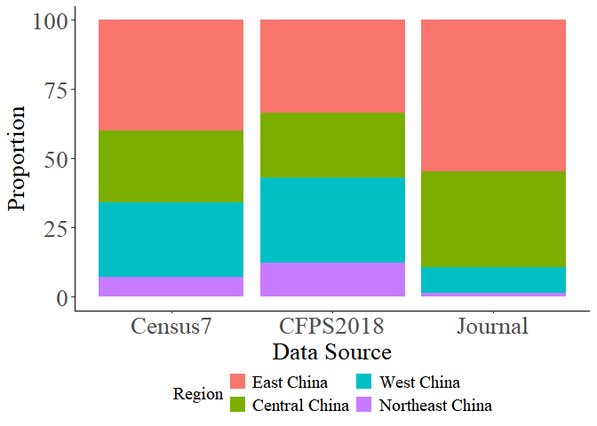

```r
H2_region_four <- full_join(Journal_region_four,Census7_region_four,
                            by = "Region_four") %>%
  dplyr::full_join(CFPS2018_region_four,by = "Region_four") %>%
  dplyr::mutate(Journal_Prop = Journal_n / sum(Journal_n)*100,
                   Census7_Prop = Census7_n / sum(Census7_n)*100,
                   CFPS2018_Prop = CFPS2018_n /sum(CFPS2018_n)*100) %>%
  dplyr::select(1,5:7)


H2_region_four2 <- H2_region_four %>%
  pivot_longer(cols = -Region_four,
             names_to = "Data Source",
             values_to = "Proportion") %>%
  dplyr::mutate(Region_four = factor(Region_four,
                                     levels = c("East China","Central China",
                                                "West China","Northeast China")))

## Visualization
H2_Fig_region_four <- ggplot(data = H2_region_four2, aes(x = `Data Source`, y = Proportion, fill = Region_four)) +
  geom_col(position = "stack")+
  labs(fill = "Region")+
  scale_x_discrete(labels =c("Journal_Prop" = "Journal",
                              "CFPS2018_Prop" = "CFPS2018",
                              "Census7_Prop" = "Census7"))+
  theme_classic()+
  theme(legend.box.spacing = unit(2,"pt"),
        legend.position = "bottom",
        legend.key.size = unit(0.5, "cm"),
        legend.text = element_text(size = 15, family = "serif"),
        legend.title = element_text(size = 15, family = "serif"),
        axis.title = element_text(size = 20,family = "serif"),
        axis.text = element_text(size = 20,family = "serif"))+
  guides(fill = guide_legend(ncol = 2))

H2_Fig_region_four
```

Visualize seven region

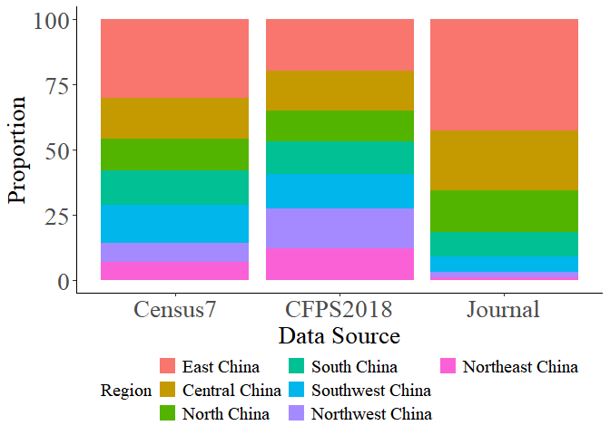

```r
H2_region_seven <- full_join(Journal_region_seven,Census7_region_seven,
                             by = "Region_seven") %>%
  dplyr::full_join(CFPS2018_region_seven,by = "Region_seven") %>%
  dplyr::mutate(Journal_Prop = Journal_n / sum(Journal_n)*100,
                   Census7_Prop = Census7_n / sum(Census7_n)*100,
                   CFPS2018_Prop = CFPS2018_n /sum(CFPS2018_n)*100) %>%
  dplyr::select(1,5:7)


H2_region_seven2 <- H2_region_seven %>%
  pivot_longer(cols = -Region_seven,
             names_to = "Data Source",
             values_to = "Proportion") %>%
  dplyr::mutate(Region_seven = factor(Region_seven,
                                     levels = c("East China","Central China",
                                                "North China","South China",
                                                "Southwest China","Northwest China",
                                                "Northeast China")))

## Visualization
H2_Fig_region_seven <- ggplot(data = H2_region_seven2, aes(x = `Data Source`, y = Proportion, fill = Region_seven)) +
  geom_col(position = "stack")+
  labs(fill = "Region")+
  scale_x_discrete(labels =c("Journal_Prop" = "Journal",
                              "CFPS2018_Prop" = "CFPS2018",
                              "Census7_Prop" = "Census7"))+
  theme_classic()+
  theme(legend.box.spacing = unit(2,"pt"),
        legend.position = "bottom",
        legend.key.size = unit(0.5, "cm"),
        legend.text = element_text(size = 15, family = "serif"),
        legend.title = element_text(size = 15, family = "serif"),
        axis.title = element_text(size = 20,family = "serif"),
        axis.text = element_text(size = 20,family = "serif"))+
  guides(fill = guide_legend(ncol = 3))


H2_Fig_region_seven
```

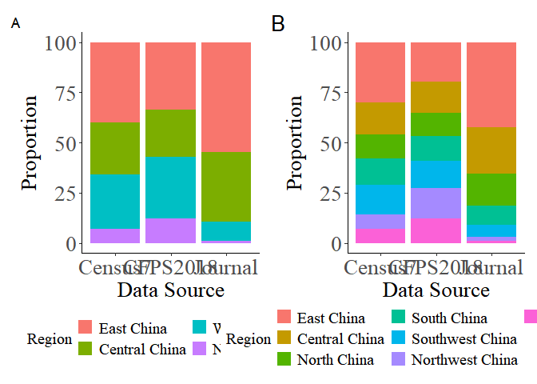

```r
H2_Fig_major_region <- H2_Fig_region_four + H2_Fig_region_seven +
plot_annotation(tag_levels = 'A',
                  theme = theme(plot.title = element_text(size = 24))) +
  theme(plot.tag = element_text(size = 20))

H2_Fig_major_region
```

```r
ggsave("H2_Fig_major_region.pdf",H2_Fig_major_region, device = "pdf", width= 15, height = 9)
```

And then, I will visualize the map for the region data of Chinese subjects Combine all region data and load color data

```r
## combine region data
Region_map_data <-  bind_rows(Census7_region,CFPS2018_region,
                              Journal_region_general_tab2)

## load color data
Region_map_color <- readxl::read_xlsx("colour.xlsx") %>%
  dplyr::mutate(QUHUADAIMA = as.character(QUHUADAIMA)) %>%
  dplyr::rename(Region = 1) %>%
  dplyr::select(-2)

## combine color data and region data
Region_data <- dplyr::left_join(Region_map_data,Region_map_color,by = join_by(Region)) %>%
  dplyr::mutate(QUHUADAIMA = ifelse(Region == "重庆", "500000", QUHUADAIMA),
                Color = ifelse(Count_Bins == "<1",1,
                               ifelse(Count_Bins == "1~5",2,
                                      ifelse(Count_Bins == "5~10",3,4))),
                Color = factor(Color, levels = c("1", "2", "3", "4"))) %>%
  tidyr::pivot_wider(names_from = Data_Source,values_from = c(Proportion, Count_Bins,n,Color)) %>%
  dplyr::mutate(across(3:ncol(.),~ifelse(is.na(.),0,.)))
```

Finally, I visualized geographic distribution and calculated Bayesian multinomial test for region.

```r
API_pre <-  "http://xzqh.mca.gov.cn/data/"
## 读取全国数据
China <-  st_read(dsn = paste0(API_pre, "quanguo.json"), stringsAsFactors=FALSE)
## 使用 4326 地理坐标系
st_crs(China) <-  4326

# 读取国界线数据
China_line <-  st_read(dsn = paste0(API_pre, "quanguo_Line.geojson"), stringsAsFactors=FALSE)
```

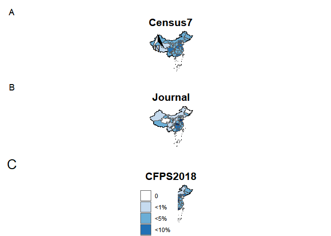

```r
st_crs(China_line) <-  4326
## 选择区划代码为国界线的区域
gjx <- China_line[China_line$QUHUADAIMA == "guojiexian",]

China <- dplyr::left_join(China,Region_data,by= "QUHUADAIMA")



## Chinese journal papers in general population
H2_Fig_region_general <- ggplot() +
  geom_sf(data = China,aes(fill = factor(Color_Journal_region_general_population))) +
  scale_fill_manual(values = c("#FFFFFF", "#C6DBEF","#6BAED6", "#2171B5", "#08306B"),
                    breaks = c("0","1","2", "3", "4"),
                    labels = c("0", "<1%","<5%", "<10%",">=10%"),drop = FALSE) +
  geom_sf(data = gjx) +
  labs(title = "Journal") +
  theme(plot.title = element_text(color = "black",size = 16,
                                  face = "bold",vjust = 0.1, hjust = 0.5),
        legend.position = "none",
        panel.grid = element_blank(),
        panel.background = element_blank(),
        axis.text = element_blank(),
        axis.ticks = element_blank(),
        axis.title = element_blank())


## CFPS2018
H2_Fig_CFPS2018_region <- ggplot() +
  geom_sf(data = China,aes(fill = factor(Color_CFPS2018))) +
  scale_fill_manual(values = c("#FFFFFF", "#C6DBEF","#6BAED6", "#2171B5", "#08306B"),
                    breaks = c("0","1","2", "3", "4"),
                    labels = c("0", "<1%","<5%", "<10%",">=10%"),drop = FALSE) +
  geom_sf(data = gjx) +
  labs(title = "CFPS2018") +
  theme(plot.title = element_text(color = "black",size = 16,
                                  face = "bold",vjust = 0.1, hjust = 0.5),
        legend.title = element_blank(),
        legend.position = c(0.2, 0.2),
        panel.background = element_blank(),
        axis.text = element_blank(),
        axis.ticks = element_blank(),
        axis.title = element_blank())
## Census7
H2_Fig_Census7_region <- ggplot() +
  geom_sf(data = China,aes(fill = factor(Color_Census7))) +
  scale_fill_manual(values = c("#FFFFFF", "#C6DBEF","#6BAED6", "#2171B5", "#08306B"),
                    breaks = c("0","1","2", "3", "4"),
                    labels = c("0", "<1%","<5%", "<10%",">=10%"),drop = FALSE) +
  geom_sf(data = gjx) +
  labs(title = "Census7") +
  theme(plot.title = element_text(color = "black",size = 16,
                                  face = "bold",vjust = 0.1, hjust = 0.5),
        legend.position = "none",
        panel.grid = element_blank(),
        panel.background = element_blank(),
        axis.text = element_blank(),
        axis.ticks = element_blank(),
        axis.title = element_blank())+
  annotation_north_arrow(location = 'tl',which_north = 'false',
                         style = north_arrow_orienteering(),
                         height = unit(0.8, "cm"),
                         width = unit(0.6, "cm") )



H2_Fig_region <- H2_Fig_Census7_region  + H2_Fig_region_general + H2_Fig_CFPS2018_region +
  plot_layout(ncol = 1, nrow = 3, heights = c(4,4))+
  plot_annotation(tag_levels = 'A',
                  theme = theme(plot.title = element_text(size = 24))) +
  theme(plot.tag = element_text(size = 20))


ggsave("H2_Fig_region.pdf", H2_Fig_region, device = "pdf", width=10, height = 15)

H2_Fig_region
```

BF four region

```r
Journal_region_four <- Journal_region_four %>%
  dplyr::rename(n = 2) %>%
  dplyr::mutate(Data_source = "Journal")

Census7_region_four <- Census7_region_four %>%
  dplyr::rename(n = 2)%>%
  dplyr::mutate(Data_source = "Census7")

CFPS2018_region_four <- CFPS2018_region_four %>%
  dplyr::rename(n = 2)%>%
  dplyr::mutate(Data_source = "CFPS2018")


H2_region_four_bayes <- bind_rows(Journal_region_four,
                                  Census7_region_four,
                                  CFPS2018_region_four) %>%
  tidyr::pivot_wider(id_cols = Region_four,
                     names_from = Data_source,
                     values_from = n) %>%
  dplyr::mutate(Journal = Journal/sum(Journal)*100,
                Census7 = Census7/sum(Census7)*100,
                CFPS2018 = CFPS2018/sum(CFPS2018)*100) %>%
  dplyr::mutate(across(everything(),~ifelse(is.na(.),1,.)))


# sum(H2_region_four_bayes$Journal) ## 100
# sum(H2_region_four_bayes$Census7) ## 100
# sum(H2_region_four_bayes$CFPS2018)  ## 100


## BF
H2_BF_Journal_Census7_region_four <- BayesMultiNomial(dataset = H2_region_four_bayes,
                                          factor = "Region_four",
                                          observed = "Journal",
                                          expected = "Census7")

H2_BF_Journal_CFPS2018_region_four <- BayesMultiNomial(dataset = H2_region_four_bayes,
                                          factor = "Region_four",
                                          observed = "Journal",
                                          expected = "CFPS2018")
```

four regions: Journal vs Census7,8.7066207 four regions: Journal vs CFPS2018,19.7943429

BF seven region

```r
Journal_region_seven <- Journal_region_seven %>%
  dplyr::rename(n = 2) %>%
  dplyr::mutate(Data_source = "Journal")

Census7_region_seven <- Census7_region_seven %>%
  dplyr::rename(n = 2)%>%
  dplyr::mutate(Data_source = "Census7")

CFPS2018_region_seven <- CFPS2018_region_seven %>%
  dplyr::rename(n = 2)%>%
  dplyr::mutate(Data_source = "CFPS2018")


H2_region_seven_bayes <- bind_rows(Journal_region_seven,
                                  Census7_region_seven,
                                  CFPS2018_region_seven) %>%
  tidyr::pivot_wider(id_cols = Region_seven,
                     names_from = Data_source,
                     values_from = n) %>%
  dplyr::mutate(Journal = Journal/sum(Journal)*100,
                Census7 = Census7/sum(Census7)*100,
                CFPS2018 = CFPS2018/sum(CFPS2018)*100) %>%
  dplyr::mutate(across(everything(),~ifelse(is.na(.),1,.)))


## BF
H2_BF_Journal_Census7_region_seven <- BayesMultiNomial(dataset = H2_region_seven_bayes,
                                          factor = "Region_seven",
                                          observed = "Journal",
                                          expected = "Census7")

H2_BF_Journal_CFPS2018_region_seven <- BayesMultiNomial(dataset = H2_region_seven_bayes,
                                          factor = "Region_seven",
                                          observed = "Journal",
                                          expected = "CFPS2018")
```

seven regions: Journal vs Census7,4.1308434 seven regions: Journal vs CFPS2018,22.2297114

save region data for exploration analysis

```r
save(Journal_region_single,Journal_region_multiple,
     Census7_region,Census7_region_four,Census7_region_seven,
     CFPS2018_region,CFPS2018_region_four,CFPS2018_region_seven,
     H2_region_four_bayes,H2_region_seven_bayes,Region_map_color,
     China_province,China_region_four,China_region_seven,
     H2_region_four,H2_region_seven,Journal_region_general_tab2,
     file = "Journal_region.RData")
```

## Test the 3rd hypothesis

### Gender

As with the first two hypotheses, I dealt with gender data first.

```r
BTS_gender_allcountry <- lapply(BTS_gender_list, function(df){

  df %>%
    dplyr::select(ISO3,Data_Source,Gender)

})

BTS_gender_allcountry <- do.call(rbind, BTS_gender_allcountry)


## filter > 30
BTS_gender_allcountry_filter <- BTS_gender_allcountry %>%
  dplyr::group_by(ISO3) %>%
  dplyr::summarise(n=n()) %>%
  dplyr::filter(n > 30) %>%
  dplyr::pull(ISO3)


H3_BTS_gender <- BTS_gender_allcountry %>%
  dplyr::filter(ISO3 %in% BTS_gender_allcountry_filter) %>% ## filter > 30
  dplyr::filter(Data_Source != "BTS_Lucca_et_al_2024") %>% ## remove special target population
  dplyr::group_by(ISO3,Gender) %>%
  dplyr::summarise(n = n()) %>%
  dplyr::ungroup() %>%
  dplyr::mutate(Data_Source = "BTS")
## Add journal gender data
## Chinese journal data please see data.frame "H1_gender_general"
H3_BTS_Journal_gender  <- H3_BTS_gender  %>%
  dplyr::mutate(n = ifelse(ISO3 == "CHN" & Gender == "Male", 13833 + 48059,n),
                n = ifelse(ISO3 == "CHN" & Gender == "Female", 13723 + 57570,n))

H3_BTS_Journal_gender_prop <- H3_BTS_Journal_gender %>%
  dplyr::group_by(ISO3) %>%
  dplyr::mutate(Proportion = n/sum(n)*100) %>%
  dplyr::ungroup()


H3_BTS_Journal_gender_sum_prop <- H3_BTS_Journal_gender_prop %>%
  dplyr::group_by(ISO3) %>%
  dplyr::mutate(sum = sum(Proportion)) %>%
  dplyr::ungroup()


## Set factor levels according to gender proportion
H3_BTS_Journal_gender_factor <- H3_BTS_Journal_gender_prop %>%
  dplyr::filter(Gender == "Female") %>%
  dplyr::arrange(Proportion) %>%
  dplyr::pull(ISO3)


## combine WEIRD data to visualization
WEIRD_gender <- WEIRD %>%
  dplyr::filter(!is.na(iso3c)) %>%
  dplyr::filter(iso3c %in% H3_BTS_Journal_gender_factor)


H3_gender <- H3_BTS_Journal_gender_prop %>%
  dplyr::left_join(WEIRD_gender,by = c("ISO3" = "iso3c")) %>%
  dplyr::mutate(WEIRD = ifelse(ISO3 == "XKX","WEIRD",WEIRD)) %>%
  dplyr::mutate(ISO3 = factor(ISO3,levels = H3_BTS_Journal_gender_factor)) %>%
  dplyr::filter(!is.na(ISO3)) %>%
  dplyr::rename(Sex = 2)
```

and I visualized gender data.

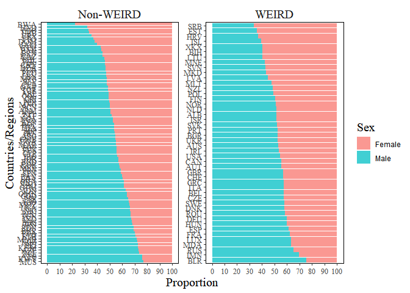

```r
H3_Fig_gender <- ggplot(H3_gender, aes(x=Proportion, y=ISO3,fill=Sex)) +
  geom_col(alpha = .75)+
  labs(y="Countries/Regions") +
  scale_fill_discrete(label=c("Female","Male")) +
  theme_classic()+
  theme(legend.title = element_text(size = 15,family = "serif"),
        axis.title= element_text(size = 15,family = "serif"),
        axis.text = element_text(size = 10,family = "serif"),
        strip.text = element_text(size = 15,family = "serif"),
        strip.background = element_rect(fill = NA,color = NA),
        panel.border = element_rect(fill = NA,color = "black")) +
  scale_x_continuous(breaks = seq(0, 100, by = 10)) +
  facet_wrap(~ WEIRD, scales = "free",
              labeller = as_labeller(c("Non_WEIRD" = "Non-WEIRD", "WEIRD" = "WEIRD")))


H3_Fig_gender
```

```r
# SLO From Psychological_Science_Accelerator_Self_Determination_Theory_Collaboration_2022
# BRG  and SRP from Ruggeri_et_al_2022


## How many countries more than China
H3_female_more60 <- H3_gender %>%
  dplyr::filter(Sex == "Female") %>%
  dplyr::filter(Proportion > 60)


H3_male_more60 <- H3_gender %>%
  dplyr::filter(Sex == "Male") %>%
  dplyr::filter(Proportion > 60)
```

Secondly, I processed age data. Similarity, I processed age data in two classification. The one is PsyStages.

```r
## filter > 30
BTS_Psystages_allcountry_filter <-  BTS_age_PsyStages %>%
  dplyr::filter(Article_Id != "Lucca_et_al_2024") %>%  ## filter target population is a and 3
  dplyr::group_by(ISO3) %>%
  dplyr::summarise(n=n()) %>%
  dplyr::filter(n > 30) %>%
  dplyr::ungroup() %>%
  dplyr::pull(ISO3)


BTS_Psystages_allcountry <- BTS_age_PsyStages %>%
  dplyr::filter(ISO3 %in% BTS_Psystages_allcountry_filter) %>%
  dplyr::filter(ISO3 != "CHN") %>% ## drop Chinese data
  dplyr::group_by(ISO3,ageBins) %>%
  dplyr::summarise(n=n()) %>%
  dplyr::mutate(Proportion = n/sum(n)*100) %>%
  dplyr::ungroup()
## calculate total sum
BTS_Psystages_allcountry_sum_prop <- BTS_Psystages_allcountry %>%
  dplyr::group_by(ISO3) %>%
  dplyr::summarise(sum = sum(Proportion)) %>%
  dplyr::ungroup()


## Add Chinese data
Journal_BTS_PsyStages_CHN <- H2_age_Psystages_bayes_general %>%
  dplyr::mutate(ISO3 = "CHN") %>%
  dplyr::rename(Proportion = `Chinese participants`) %>%
  dplyr::select(-Census7)

sum(Journal_BTS_PsyStages_CHN$Proportion)
```

```
## [1] 100
```

```r
## Combine data
H3_PsyStages <- dplyr::bind_rows(BTS_Psystages_allcountry,Journal_BTS_PsyStages_CHN)

# table(H3_PsyStages$ageBins)

## Set factor
H3_PsyStages_factor <- H3_PsyStages %>%
  dplyr::filter(ageBins == "18~25") %>%
  dplyr::arrange(Proportion) %>%
  dplyr::pull(ISO3)

## Process WEIRD
H3_PsyStages2 <- H3_PsyStages %>%
  dplyr::left_join(WEIRD, by = c("ISO3" = "iso3c")) %>%
  dplyr::mutate(WEIRD = ifelse(ISO3 == "XKX","WEIRD",WEIRD)) %>%
  dplyr::mutate(ISO3 = factor(ISO3, levels = H3_PsyStages_factor)) %>%
  dplyr::filter(!is.na(ageBins)) %>%
  dplyr::rename(`Age bins` = 2)


## The prop of 18~25 more than 60%
H3_PsyStages2_more60 <- H3_PsyStages2 %>%
  dplyr::filter(`Age bins` == "18~25") %>%
  dplyr::filter(Proportion > 60)
```

And I visualized age data (PsyStages) for all countries in BTS.

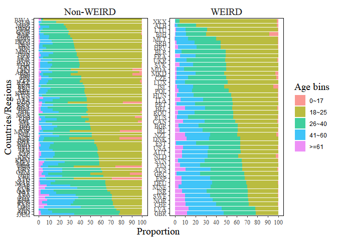

```r
H3_Fig_PsyStages <- ggplot(H3_PsyStages2, aes(x=Proportion, y=ISO3, fill=`Age bins`)) +
  geom_col(alpha = .75)+
  labs(y="Countries/Regions") +
  scale_fill_discrete(label=c("0~17", "18~25", "26~40", "41~60",">=61" )) +
  theme_classic()+
  #guides(y="axis_nested") +
  theme(legend.title = element_text(size = 15,family = "serif"),
        axis.title= element_text(size = 15,family = "serif"),
        axis.text = element_text(size = 10,family = "serif"),
        strip.text = element_text(size = 15,family = "serif"),
        strip.background = element_rect(fill = NA,color = NA),
        panel.border = element_rect(fill = NA,color = "black")) +
  scale_x_continuous(breaks = seq(0, 100, by = 10)) +
  facet_wrap(~ WEIRD, scales = "free",
             labeller = as_labeller(c("Non_WEIRD" = "Non-WEIRD", "WEIRD" = "WEIRD")))


H3_Fig_PsyStages
```

The other is 10-year-old.

```r
## Filter > 30
BTS_interval10_allcountry_filter <-  BTS_age_interval10 %>%
  dplyr::filter(Article_Id != "Lucca_et_al_2024") %>%  ## filter target population is a and 3
  dplyr::group_by(ISO3) %>%
  dplyr::summarise(n=n()) %>%
  dplyr::filter(n > 30) %>%
  dplyr::ungroup() %>%
  dplyr::pull(ISO3)


BTS_interval10_allcountry <- BTS_age_interval10 %>%
  dplyr::filter(ISO3 %in% BTS_interval10_allcountry_filter) %>%
  dplyr::filter(ISO3 != "CHN") %>%  ## drop Chinese data
  dplyr::group_by(ISO3,ageBins) %>%
  dplyr::summarise(n=n()) %>%
  dplyr::mutate(Proportion = n/sum(n)*100) %>%
  dplyr::ungroup()
## ## calculate total sum
BTS_interval10_allcountry_sum_prop <- BTS_interval10_allcountry %>%
  dplyr::group_by(ISO3) %>%
  dplyr::summarise(sum = sum(Proportion)) %>%
  dplyr::ungroup()


## Add Chinese data
Journal_BTS_interval10_CHN <- H2_age_inteval10_bayes_general %>%
  dplyr::mutate(ISO3 = "CHN") %>%
  dplyr::rename(Proportion = `Chinese participants`) %>%
  dplyr::select(-Census7)


## Combine data
H3_interval10 <- bind_rows(BTS_interval10_allcountry,Journal_BTS_interval10_CHN)


## Set factor
H3_interval10_factor <- H3_interval10 %>%
  dplyr::filter(ageBins == "11~20") %>%
  dplyr::arrange(Proportion) %>%
  dplyr::pull(ISO3)


## Process WEIRD
H3_interval10 <- H3_interval10 %>%
  dplyr::left_join(WEIRD, by = c("ISO3" = "iso3c")) %>%
  dplyr::mutate(WEIRD = ifelse(ISO3 == "XKX","WEIRD",WEIRD)) %>%
  dplyr::mutate(ISO3 = factor(ISO3, levels = H3_interval10_factor)) %>%
  dplyr::filter(!is.na(ageBins) & !is.na(ISO3)) %>%
  dplyr::rename(`Age bins` = 2)


## each countries the max agebins
H3_interval10_max_agebins <-  H3_interval10 %>%
  dplyr::group_by(ISO3) %>%
  dplyr::mutate(Rank = dense_rank(desc(Proportion))) %>%
  dplyr::filter(Rank == 1)

# table(H3_interval10_max_agebins$ageBins)
```

and I visualized age data (interval10) of all countries in BTS.

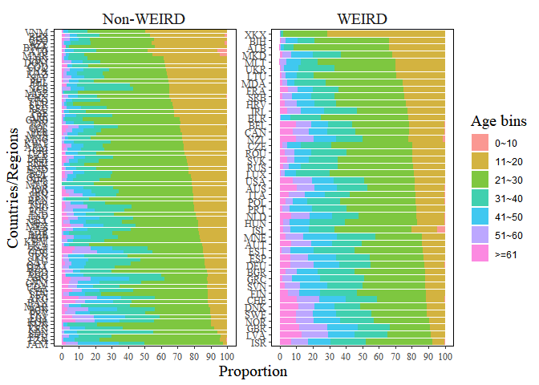

```r
H3_Fig_interval10 <- ggplot(H3_interval10, aes(x=Proportion, y=ISO3, fill=`Age bins`)) +
  geom_col(alpha = .75)+
  labs(y="Countries/Regions") +
  scale_fill_discrete(label=c("0~10","11~20","21~30", "31~40", "41~50", "51~60", ">=61")) +
  theme_classic()+
  #guides(y="axis_nested") +
  theme(legend.title = element_text(size = 15,family = "serif"),
        axis.title= element_text(size = 15,family = "serif"),
        axis.text = element_text(size = 10,family = "serif"),
        strip.text = element_text(size = 15,family = "serif"),
        strip.background = element_rect(fill = NA,color = NA),
        panel.border = element_rect(fill = NA,color = "black")) +
  scale_x_continuous(breaks = seq(0, 100, by = 10)) +
  facet_wrap(~ WEIRD, scales = "free",
              labeller = as_labeller(c("Non_WEIRD" = "Non-WEIRD", "WEIRD" = "WEIRD")))


H3_Fig_interval10
```

After the visualization of complete, I calculated BF. Firstly I defined a function to calculating BF for multiple countries.

```r
# create a new variable to store the BF values
Func_BFpairs <- function(df, countries_order, prop_name){

  # create a temp variable for storing
  BF_mult_tmp <- data.frame(matrix(nrow = 0, ncol = 5))
  colnames(BF_mult_tmp) <- c("Observed", "Expected", "Log(BF10)_NonInform", "BF10_NonInform", "BF01_NonInform")

  for (ii in seq(length(countries_order))){
    country <- countries_order[ii]
    if (country != "CHN"){
      df_tmp <- df %>% dplyr::select(prop_name, one_of(country), "CHN")

      BF_tmp <- BayesMultiNomial(dataset = df_tmp,
                                 factor = prop_name, observed = country, expected = "CHN")

      BF_mult_tmp[ii,] <- c(as.character(country), "CHN",
                            BF_tmp$BF$LogBF10, BF_tmp$BF$BF10, BF_tmp$BF$BF01)
    }
  }

  countries_order_age <- BF_mult_tmp %>%
    tidyr::drop_na() %>%
    dplyr::mutate(`Log(BF10)_NonInform` = as.numeric(`Log(BF10)_NonInform`)) %>%
    dplyr::arrange(`Log(BF10)_NonInform`) %>%
    dplyr::pull(Observed)

  BF_mult_p_tmp <- BF_mult_tmp %>%
    tidyr::drop_na() %>%
    dplyr::select(1,2,3) %>%
    dplyr::mutate(Countries = factor(Observed, levels = countries_order_age),
                  `Log(BF10)_NonInform` = as.numeric(`Log(BF10)_NonInform`))

  return(BF_mult_p_tmp)
}
```

Secondly , I calculated gender BF and visualized gender BF.

```r
H3_BF_gender <- H3_gender %>%
  dplyr::select(ISO3,Sex,Proportion) %>%
  dplyr::rename(Countries = 1)


H3_BF_gender_factor <- H3_BF_gender %>%
  dplyr::filter(Sex == "Female") %>%
  dplyr::arrange(Proportion) %>%
  dplyr::pull(Countries)


H3_BF_gender <- H3_BF_gender  %>%
  dplyr::mutate(Countries = factor(Countries, levels = H3_BF_gender_factor)) %>%
  tidyr::pivot_wider(names_from = "Countries",values_from = "Proportion") %>%
  Func_BFpairs(countries_order = H3_BF_gender_factor,
               prop_name = "Sex") %>%
  dplyr::rename("Countries/Regions" = "Countries")

## moderate evidence support H0
H3_BF_gender_supportH0 <- H3_BF_gender %>%
  dplyr::filter(`Log(BF10)_NonInform` < log(1/6))

## moderate evidence support H1
H3_BF_gender_supportH1 <- H3_BF_gender %>%
  dplyr::filter(`Log(BF10)_NonInform` > log(6))

## female and male
H3_gender_different <- H3_gender %>%
  dplyr::filter(ISO3 %in% H3_BF_gender_supportH1$Observed) %>%
  dplyr::filter(Sex == "Female")
```

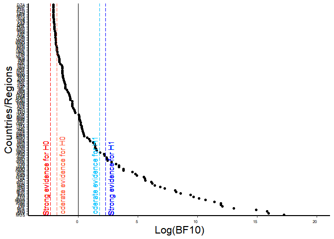

```r
H3_Fig_BF_gender <- ggplot(H3_BF_gender, aes( x = `Log(BF10)_NonInform`, y = `Countries/Regions`)) +
  geom_point() +
  scale_color_grey() +
  xlim(-3, 20) +
  scale_y_discrete(limits=rev) +
  geom_vline(xintercept = c(log(1/10), log(1/6), 0, log(6), log(10)),
             colour = c("red", "tomato", "black", "deepskyblue","blue"),
             linetype=c("longdash", "longdash", "solid", "longdash","longdash")) +
  geom_text(aes(x=log(10), label="\nStrong evidence for H1", y = 23), colour="blue", alpha = 0.7,
            angle=90, text=element_text(size=10)) +
  geom_text(aes(x=log(6), label="Moderate evidence for H1\n", y = 23), colour="deepskyblue", alpha = 0.7,
            angle=90, text=element_text(size=10)) +
  geom_text(aes(x=log(1/6), label="\nModerate evidence for H0", y = 23), colour="tomato", alpha = 0.7,
            angle=90, text=element_text(size=10)) +
  geom_text(aes(x=log(1/10), label="Strong evidence for H0\n", y = 23), colour="red", alpha = 0.7,
            angle=90, text=element_text(size=10)) +
  xlab("Log(BF10)")+
  theme_bw() +
        theme(panel.grid.major = element_blank(),
              panel.grid.minor = element_blank(),
              panel.background = element_blank(),
              panel.border = element_blank(),
              text = element_text(family='Times'),
              axis.text.x = element_text (size = 6, color = 'black',  hjust = 1),
              axis.text.y = element_text (size = 6, color = 'black'),
              plot.title = element_text(lineheight=.8, face="bold", size = 18, margin=margin(0,0,20,0)),
              axis.text = element_text (size = 6, color = 'black'),
              axis.title = element_text (size = 16),
              axis.title.x = element_text (size = 16),
              axis.title.y = element_text( size = 16),
              axis.line.x = element_line(color='black', size = 1),
              axis.line.y = element_line(color='black', size = 1))


H3_Fig_BF_gender
```

Third, I calculted age BF in two classification. In this part, I calculated BF for this two categories.

PsyStages

```r
## PsyStages
H3_BF_PsyStages <- H3_PsyStages2 %>%
  dplyr::select(ISO3,`Age bins`,Proportion) %>%
  dplyr::filter(!is.na(ISO3)) %>%
  dplyr::rename(Countries = 1)

table(H3_BF_PsyStages$`Age bins`)
```

```
##
##  <=17 18~25 26~40 41~60  >=61
##    85   128   128   126   117
```

```r
H3_BF_PsyStages_factor <- H3_BF_PsyStages %>%
  dplyr::filter(`Age bins` == "18~25") %>%
  dplyr::arrange(Proportion) %>%
  dplyr::pull(Countries)



H3_BF_PsyStages <- H3_BF_PsyStages %>%
  dplyr::mutate(Countries = factor(Countries,
                                             levels = H3_BF_PsyStages_factor)) %>%
  tidyr::pivot_wider(names_from = "Countries",values_from = "Proportion") %>%
  dplyr::mutate(across(2:last_col(), ~ifelse(is.na(.), 0, .))) %>%
  Func_BFpairs(countries_order = H3_BF_PsyStages_factor,
               prop_name = "Age bins") %>%
  dplyr::rename("Countries/Regions" = "Countries")

# sum(H3_BF_PsyStages$AGO,na.rm = TRUE) ## 0

## moderate evidence support H0
H3_BF_PsyStages_supportH0 <- H3_BF_PsyStages %>%
  dplyr::filter(`Log(BF10)_NonInform` < log(1/6))
```

interval10

```r
H3_BF_interval10  <- H3_interval10 %>%
  dplyr::select(ISO3,`Age bins`,Proportion) %>%
  dplyr::rename(Countries = 1)


H3_BF_interval10_factor <- H3_BF_interval10 %>%
  dplyr::filter(`Age bins` == "11~20") %>%
  dplyr::arrange(Proportion) %>%
  dplyr::pull(Countries)


table(H3_BF_interval10$`Age bins`)
```

```
##
##  <=10 11~20 21~30 31~40 41~50 51~60  >=61
##    34   128   128   128   125   123   117
```

```r
H3_BF_interval10 <- H3_BF_interval10 %>%
  dplyr::mutate(Countries = factor(Countries,
                                   levels = H3_BF_interval10_factor)) %>%
  tidyr::pivot_wider(names_from = "Countries",values_from = "Proportion") %>%
  dplyr::mutate(across(2:last_col(), ~ifelse(is.na(.), 1, .))) %>%
  Func_BFpairs(countries_order = H3_BF_PsyStages_factor,
               prop_name = "Age bins")%>%
  dplyr::rename("Countries/Regions" = "Countries")


## moderate evidence support H0
H3_BF_interval10_supportH0 <- H3_BF_interval10 %>%
  dplyr::filter(`Log(BF10)_NonInform` < log(1/6))
```

and I visualized PsyStages BF at first.

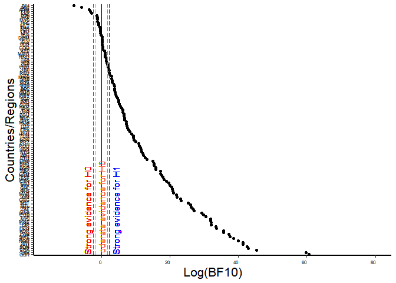

```r
H3_Fig_BF_PsyStages <- ggplot(H3_BF_PsyStages, aes( x = `Log(BF10)_NonInform`,
                                                    y = `Countries/Regions`)) +
  geom_point() +
  scale_color_grey() +
  xlim(-15,80) +
  scale_y_discrete(limits=rev) +
  geom_vline(xintercept = c(log(1/10), log(1/6), 0, log(6), log(10)),
             colour = c("red", "tomato", "black", "deepskyblue","blue"),
             linetype=c("longdash", "longdash", "solid", "longdash","longdash")) +
  geom_text(aes(x=log(10), label="\nStrong evidence for H1", y = 23), colour="blue", alpha = 0.7,
            angle=90, text=element_text(size=10)) +
  geom_text(aes(x=log(6), label="Moderate evidence for H1\n", y = 23), colour="deepskyblue", alpha = 0.7,
            angle=90, text=element_text(size=10)) +
  geom_text(aes(x=log(1/6), label="\nModerate evidence for H0", y = 23), colour="tomato", alpha = 0.7,
            angle=90, text=element_text(size=10)) +
  geom_text(aes(x=log(1/10), label="Strong evidence for H0\n", y = 23), colour="red", alpha = 0.7,
            angle=90, text=element_text(size=10))  +
  xlab("Log(BF10)")+
  theme_bw() +
        theme(panel.grid.major = element_blank(),
              panel.grid.minor = element_blank(),
              panel.background = element_blank(),
              panel.border = element_blank(),
              text = element_text(family='Times'),
              axis.text.x = element_text (size = 6, color = 'black',  hjust = 1),
              axis.text.y = element_text (size = 6, color = 'black'),
              plot.title = element_text(lineheight=.6, face="bold", size = 18, margin=margin(0,0,20,0)),
              axis.text = element_text (size = 10, color = 'black'),
              axis.title = element_text (size = 16),
              axis.title.x = element_text (size = 16),
              axis.title.y = element_text( size = 16),
              axis.line.x = element_line(color='black', size = 1),
              axis.line.y = element_line(color='black', size = 1))

H3_Fig_BF_PsyStages
```

Then I visualized another category.

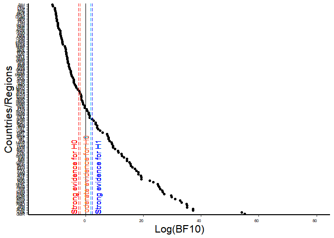

```r
H3_Fig_BF_interval10 <- ggplot(H3_BF_interval10,
                            aes( x = `Log(BF10)_NonInform`, y = `Countries/Regions`)) +
  geom_point() +
  scale_color_grey() +
  xlim(-15,80) +
  scale_y_discrete(limits=rev) +
  geom_vline(xintercept = c(log(1/10), log(1/6), 0, log(6), log(10)),
             colour = c("red", "tomato", "black", "deepskyblue","blue"),
             linetype=c("longdash", "longdash", "solid", "longdash","longdash")) +
  geom_text(aes(x=log(10), label="\nStrong evidence for H1", y = 23), colour="blue", alpha = 0.7,
            angle=90, text=element_text(size=10)) +
  geom_text(aes(x=log(6), label="Moderate evidence for H1\n", y = 23), colour="deepskyblue", alpha = 0.7,
            angle=90, text=element_text(size=10)) +
  geom_text(aes(x=log(1/6), label="\nModerate evidence for H0", y = 23), colour="tomato", alpha = 0.7,
            angle=90, text=element_text(size=10)) +
  geom_text(aes(x=log(1/10), label="Strong evidence for H0\n", y = 23), colour="red", alpha = 0.7,
            angle=90, text=element_text(size=10))  +
  xlab("Log(BF10)")+
  theme_bw() +
        theme(panel.grid.major = element_blank(),
              panel.grid.minor = element_blank(),
              panel.background = element_blank(),
              panel.border = element_blank(),
              text = element_text(family='Times'),
              axis.text.x = element_text (size = 6, color = 'black',  hjust = 1),
              axis.text.y = element_text (size = 6, color = 'black'),
              plot.title = element_text(lineheight=.8, face="bold", size = 18, margin=margin(0,0,20,0)),
              axis.text = element_text (size = 6, color = 'black'),
              axis.title = element_text (size = 16),
              axis.title.x = element_text (size = 16),
              axis.title.y = element_text( size = 16),
              axis.line.x = element_line(color='black', size = 1),
              axis.line.y = element_line(color='black', size = 1))

H3_Fig_BF_interval10
```

Finally, I combined the these fig, as well as the figure that suppl document.

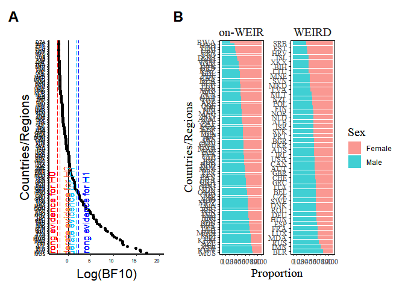

```r
## gender
H3_Fig_gender2 <- H3_Fig_BF_gender + H3_Fig_gender +
  plot_annotation(tag_levels = 'A')  &
  theme(plot.tag = element_text(size = 18, face = "bold"))

ggsave("H3_Fig_gender.pdf", H3_Fig_gender2, device = "pdf", width=18, height = 18)

H3_Fig_gender2
```

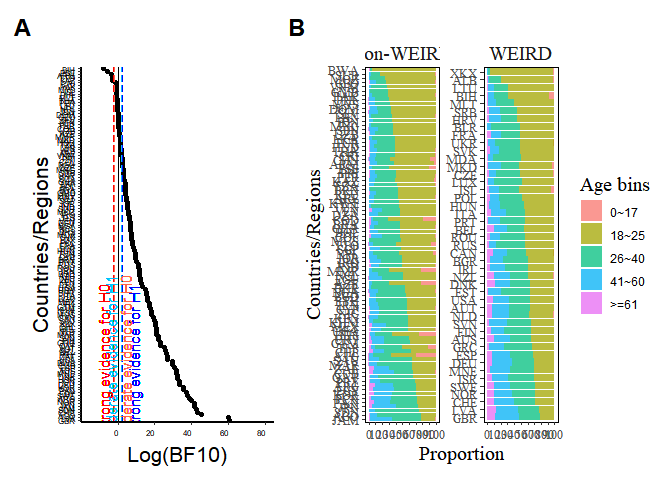

```r
## age
H3_Fig_age <- H3_Fig_BF_PsyStages + H3_Fig_PsyStages +
  plot_annotation(tag_levels = 'A')  &
  theme(plot.tag = element_text(size = 18, face = "bold"))

ggsave("H3_Fig_age.pdf", H3_Fig_age, device = "pdf", width=18, height = 18)

H3_Fig_age
```